# Visualization and analysis for Simes dendrochronology ms.

Load required libraries

```r
library(dplR)
library(zoo)
```

```r
library(ggplot2)
library(gdata)
library(grid)
library(mgcv)
library(akima)
library(spatstat)
```

Generate required custom functions filled.contour3 and multiplot

filled.contour3 from: http://wiki.cbr.washington.edu/qerm/sites/qerm/images/1/16/Filled.contour3.R

Multiplot is from R cookbook: http://www.cookbook-r.com/Graphs/Multiple_graphs_on_one_page_%28ggplot2%29/

```r
filled.contour3 <- function(x = seq(0, 1, length.out = nrow(z)), y = seq(0,
    1, length.out = ncol(z)), z, xlim = range(x, finite = TRUE), ylim = range(y,
    finite = TRUE), zlim = range(z, finite = TRUE), levels = pretty(zlim, nlevels),
    nlevels = 20, color.palette = cm.colors, col = color.palette(length(levels) -
        1), plot.title, plot.axes, key.title, key.axes, asp = NA, xaxs = "i",
    yaxs = "i", las = 1, axes = TRUE, frame.plot = axes, mar, ...) {
    # modification by Ian Taylor of the filled.contour function to remove the
    # key and facilitate overplotting with contour() further modified by Carey
    # McGilliard and Bridget Ferris to allow multiple plots on one page

    if (missing(z)) {
        if (!missing(x)) {
            if (is.list(x)) {
                z <- x$z
                y <- x$y
                x <- x$x
            } else {
                z <- x
                x <- seq.int(0, 1, length.out = nrow(z))
            }
        } else stop("no 'z' matrix specified")
    } else if (is.list(x)) {
        y <- x$y
        x <- x$x
    }
    if (any(diff(x) <= 0) || any(diff(y) <= 0))
        stop("increasing 'x' and 'y' values expected")
    # mar.orig <- (par.orig <- par(c('mar', 'las', 'mfrow')))$mar
    # on.exit(par(par.orig)) w <- (3 + mar.orig[2]) * par('csi') * 2.54 par(las
    # = las) mar <- mar.orig
    plot.new()
    # par(mar=mar)
    plot.window(xlim, ylim, "", xaxs = xaxs, yaxs = yaxs, asp = asp)
    if (!is.matrix(z) || nrow(z) <= 1 || ncol(z) <= 1)
        stop("no proper 'z' matrix specified")
    if (!is.double(z))
        storage.mode(z) <- "double"
    .filled.contour(as.double(x), as.double(y), z, as.double(levels), col = col)
    if (missing(plot.axes)) {
        if (axes) {
            title(main = "", xlab = "", ylab = "")
            Axis(x, side = 1)
            Axis(y, side = 2)
        }
    } else plot.axes
    if (frame.plot)
        box()
    if (missing(plot.title))
        title(...) else plot.title
    invisible()
}


# Multiple plot function ggplot objects can be passed in ..., or to plotlist
# (as a list of ggplot objects) - cols: Number of columns in layout -
# layout: A matrix specifying the layout. If present, 'cols' is ignored.  If
# the layout is something like matrix(c(1,2,3,3), nrow=2, byrow=TRUE), then
# plot 1 will go in the upper left, 2 will go in the upper right, and 3 will
# go all the way across the bottom.
multiplot <- function(..., plotlist = NULL, file, cols = 1, layout = NULL) {
    require(grid)

    # Make a list from the ... arguments and plotlist
    plots <- c(list(...), plotlist)

    numPlots = length(plots)

    # If layout is NULL, then use 'cols' to determine layout
    if (is.null(layout)) {
        # Make the panel ncol: Number of columns of plots nrow: Number of rows
        # needed, calculated from # of cols
        layout <- matrix(seq(1, cols * ceiling(numPlots/cols)), ncol = cols,
            nrow = ceiling(numPlots/cols))
    }

    if (numPlots == 1) {
        print(plots[[1]])

    } else {
        # Set up the page
        grid.newpage()
        pushViewport(viewport(layout = grid.layout(nrow(layout), ncol(layout))))

        # Make each plot, in the correct location
        for (i in 1:numPlots) {
            # Get the i,j matrix positions of the regions that contain this subplot
            matchidx <- as.data.frame(which(layout == i, arr.ind = TRUE))

            print(plots[[i]], vp = viewport(layout.pos.row = matchidx$row, layout.pos.col = matchidx$col))
        }
    }
}
```

Read in raw data files

```r
trees <- read.csv("C:/Users/aellison/Dropbox/Aaron's Briefcase/manuscript - Simes dendro and land use/analysis/trees03.csv")
dendro <- read.csv("C:/Users/aellison/Dropbox/Aaron's Briefcase/manuscript - Simes dendro and land use/analysis/hf086-01-dendro.csv")

head(trees)
```

```
##   plot sec tree genus species  dbh   cc live xcoord ycoord zelev elev0
## 1    1   C  501 Tsuga    TSCA 13.4 <NA>    D   30.1   37.6 -2.57 50;40
## 2    1   C  512 Tsuga    TSCA 29.0    C    L   30.1   51.7 -3.28 50;40
## 3    1   C  507 Tsuga    TSCA 12.3    S    L   30.8   44.5 -3.17 50;40
## 4    1   C  513 Tsuga    TSCA 43.8    D    L   31.3   55.1 -3.50 50;40
## 5    1   C  502  Acer    ACRU  9.0    S    L   31.5   40.3 -3.03 50;40
## 6    1   C  506 Tsuga    TSCA  9.9    S    L   31.8   43.5 -3.22 50;40
```

```r
head(dendro)
```

```
##   Plot Genus Species Code TreeNum Year mmperyear
## 1    1  Acer  rubrum ACRU     532 1935     1.275
## 2    1  Acer  rubrum ACRU     532 1936     1.519
## 3    1  Acer  rubrum ACRU     532 1937     1.375
## 4    1  Acer  rubrum ACRU     532 1938     0.891
## 5    1  Acer  rubrum ACRU     532 1939     0.737
## 6    1  Acer  rubrum ACRU     532 1940     1.139
```

Create contour plots of trees in each plot (ms. Figures 5, 6)

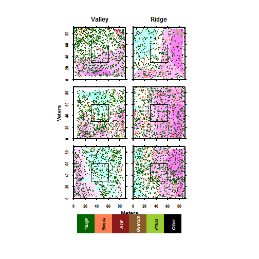

```r
# extract tree location data for each plot
attach(trees)
plot.1 <- trees[plot == 1, ]
plot.2 <- trees[plot == 2, ]
plot.3 <- trees[plot == 3, ]
plot.4 <- trees[plot == 4, ]
plot.5 <- trees[plot == 5, ]
plot.6 <- trees[plot == 6, ]
plot.7 <- trees[plot == 7, ]
plot.8 <- trees[plot == 8, ]

genera <- levels(genus)

detach(trees)

# remove NAs
p1 <- na.omit(plot.1)
p2 <- na.omit(plot.2)
p3 <- na.omit(plot.3)
p4 <- na.omit(plot.4)
p5 <- na.omit(plot.5)
p6 <- na.omit(plot.6)
p7 <- na.omit(plot.7)
p8 <- na.omit(plot.8)

# set up contour plot grids
p.1.i <- interp(p1$xcoord, p1$ycoord, scale(p1$zelev), xo = seq(0, 90, length = 40),
    yo = seq(0, 90, length = 40), duplicate = "strip", extrap = FALSE, linear = FALSE)

p.2.i <- interp(p2$xcoord, p2$ycoord, scale(p2$zelev), xo = seq(0, 90, length = 40),
    yo = seq(0, 90, length = 40), duplicate = "strip", extrap = FALSE, linear = FALSE)
p.3.i <- interp(p3$xcoord, p3$ycoord, scale(p3$zelev), xo = seq(0, 90, length = 40),
    yo = seq(0, 90, length = 40), duplicate = "strip", extrap = FALSE, linear = FALSE)
p.4.i <- interp(p4$xcoord, p4$ycoord, scale(p4$zelev), xo = seq(0, 90, length = 40),
    yo = seq(0, 90, length = 40), duplicate = "strip", extrap = FALSE, linear = FALSE)
p.5.i <- interp(p5$xcoord, p5$ycoord, scale(p5$zelev), xo = seq(0, 90, length = 40),
    yo = seq(0, 90, length = 40), duplicate = "strip", extrap = FALSE, linear = FALSE)
p.6.i <- interp(p6$xcoord, p6$ycoord, scale(p6$zelev), xo = seq(0, 90, length = 40),
    yo = seq(0, 90, length = 40), duplicate = "strip", extrap = FALSE, linear = FALSE)
p.7.i <- interp(p7$xcoord, p7$ycoord, scale(p7$zelev), xo = seq(0, 90, length = 40),
    yo = seq(0, 90, length = 40), duplicate = "strip", extrap = FALSE, linear = FALSE)
p.8.i <- interp(p8$xcoord, p8$ycoord, scale(p8$zelev), xo = seq(0, 90, length = 40),
    yo = seq(0, 90, length = 40), duplicate = "strip", extrap = FALSE, linear = FALSE)


# set color palette for genera

genera.colors.1 <- c("firebrick4", "coral", "black", "black", "black", "black",
    "black", "black", "black", "olivedrab3", "black", "tan4", "black", "darkgreen")

genera.rank <- c(14, 2, 1, 12, 10, 7, 9, 4, 11, 8, 3, 6, 5, 13)

cex.I <- c(0.6, 0.6, rep(0.3, 7), 0.6, 0.3, 0.6, 0.3, 0.6)

# begin hemlock plot uncomment pdf and dev.off() lines to generate pdfs

# pdf(file='hemlock_countors.pdf', width=4.75, height=6, colormodel='cmyk',
# pointsize=9)

layout(matrix(c(1, 6, 2, 5, 3, 4, 0, 0, 7, 7), 5, 2, byrow = TRUE), widths = rep(lcm(4.08),
    2), heights = c(rep(lcm(4.08), 3), lcm(0.75), lcm(1.5)))
# layout.show(7)
par(pin = c(1.75, 1.75), plt = c(0.0625, 0.9375, 0.0625, 0.9375))


filled.contour3(p.1.i, xlim = c(0, 90), ylim = c(0, 90), axes = FALSE, nlevels = 5)

for (i in 1:length(genera)) {
    points(plot.1$xcoord[plot.1$genus == genera[i]], plot.1$ycoord[plot.1$genus ==
        genera[i]], col = genera.colors.1[i], pch = 19, cex = cex.I[i])
}
axis(1, at = seq(0, 80, 20), labels = FALSE, tcl = -0.25, lwd = 2)
axis(2, at = seq(0, 80, 20), labels = TRUE, tcl = -0.25, lwd = 2, font.axis = 2)
axis(3, at = seq(0, 80, 20), labels = FALSE, tcl = -0.25, lwd = 2)
axis(4, at = seq(0, 80, 20), labels = FALSE, tcl = -0.25, lwd = 2)
box(lwd = 2)
rect(30, 30, 60, 60, border = "black", lty = "solid", lwd = 1)
mtext("Valley", side = 3, font = 2, padj = -1, cex = 1)

filled.contour3(p.2.i, xlim = c(0, 90), ylim = c(0, 90), axes = FALSE, nlevels = 5)

for (i in 1:length(genera)) {
    points(plot.2$xcoord[plot.2$genus == genera[i]], plot.2$ycoord[plot.2$genus ==
        genera[i]], col = genera.colors.1[i], pch = 19, cex = cex.I[i])
}
axis(1, at = seq(0, 80, 20), labels = FALSE, tcl = -0.25, lwd = 2)
axis(2, at = seq(0, 80, 20), labels = TRUE, tcl = -0.25, lwd = 2, font.axis = 2)
axis(3, at = seq(0, 80, 20), labels = FALSE, tcl = -0.25, lwd = 2)
axis(4, at = seq(0, 80, 20), labels = FALSE, tcl = -0.25, lwd = 2)
box(lwd = 2)
rect(30, 30, 60, 60, border = "black", lty = "solid", lwd = 1)

mtext("Meters", side = 2, font = 2, padj = -3, cex = 0.85)

filled.contour3(p.3.i, xlim = c(0, 90), ylim = c(0, 90), axes = FALSE, nlevels = 5)

for (i in 1:length(genera)) {
    points(plot.3$xcoord[plot.3$genus == genera[i]], plot.3$ycoord[plot.3$genus ==
        genera[i]], col = genera.colors.1[i], pch = 19, cex = cex.I[i])
}
axis(1, at = seq(0, 80, 20), labels = TRUE, tcl = -0.25, lwd = 2, font.axis = 2)
axis(2, at = seq(0, 80, 20), labels = TRUE, tcl = -0.25, lwd = 2, font.axis = 2)
axis(3, at = seq(0, 80, 20), labels = FALSE, tcl = -0.25, lwd = 2)
axis(4, at = seq(0, 80, 20), labels = FALSE, tcl = -0.25, lwd = 2)
box(lwd = 2)
rect(30, 30, 60, 60, border = "black", lty = "solid", lwd = 1)

filled.contour3(p.4.i, xlim = c(0, 90), ylim = c(0, 90), axes = FALSE, nlevels = 5)

for (i in 1:length(genera)) {
    points(plot.4$xcoord[plot.4$genus == genera[i]], plot.4$ycoord[plot.4$genus ==
        genera[i]], col = genera.colors.1[i], pch = 19, cex = cex.I[i])
}
axis(1, at = seq(0, 80, 20), labels = TRUE, tcl = -0.25, lwd = 2, font.axis = 2)
axis(2, at = seq(0, 80, 20), labels = FALSE, tcl = -0.25, lwd = 2)
axis(3, at = seq(0, 80, 20), labels = FALSE, tcl = -0.25, lwd = 2)
axis(4, at = seq(0, 80, 20), labels = FALSE, tcl = -0.25, lwd = 2)
box(lwd = 2)
rect(30, 30, 60, 60, border = "black", lty = "solid", lwd = 1)

mtext("Meters", side = 1, font = 2, padj = 3, adj = -0.35, cex = 0.85)

filled.contour3(p.5.i, xlim = c(0, 90), ylim = c(0, 90), axes = FALSE, nlevels = 5)

for (i in 1:length(genera)) {
    points(plot.5$xcoord[plot.5$genus == genera[i]], plot.5$ycoord[plot.5$genus ==
        genera[i]], col = genera.colors.1[i], pch = 19, cex = cex.I[i])
}
axis(1, at = seq(0, 80, 20), labels = FALSE, tcl = -0.25, lwd = 2)
axis(2, at = seq(0, 80, 20), labels = FALSE, tcl = -0.25, lwd = 2)
axis(3, at = seq(0, 80, 20), labels = FALSE, tcl = -0.25, lwd = 2)
axis(4, at = seq(0, 80, 20), labels = FALSE, tcl = -0.25, lwd = 2)
box(lwd = 2)
rect(30, 30, 60, 60, border = "black", lty = "solid", lwd = 1)


filled.contour3(p.6.i, xlim = c(0, 90), ylim = c(0, 90), axes = FALSE, nlevels = 5)

for (i in 1:length(genera)) {
    points(plot.6$xcoord[plot.6$genus == genera[i]], plot.6$ycoord[plot.6$genus ==
        genera[i]], col = genera.colors.1[i], pch = 19, cex = cex.I[i])
}
axis(1, at = seq(0, 80, 20), labels = FALSE, tcl = -0.25, lwd = 2)
axis(2, at = seq(0, 80, 20), labels = FALSE, tcl = -0.25, lwd = 2)
axis(3, at = seq(0, 80, 20), labels = FALSE, tcl = -0.25, lwd = 2)
axis(4, at = seq(0, 80, 20), labels = FALSE, tcl = -0.25, lwd = 2)
box(lwd = 2)
rect(30, 30, 60, 60, border = "black", lty = "solid", lwd = 1)

mtext("Ridge", side = 3, font = 2, padj = -1, cex = 1)

genera.colors.1 <- c("firebrick4", "coral", "black", "black", "black", "black",
    "black", "black", "black", "olivedrab3", "black", "tan4", "black", "darkgreen")

genera.rank <- c(14, 2, 1, 12, 10, 7, 9, 4, 11, 8, 3, 6, 5, 13)

image(1:6, 1, as.matrix(1:6), col = genera.colors.1[genera.rank[1:6]], xlab = "",
    ylab = "", xaxt = "n", yaxt = "n", bty = "n")
blacks <- c(2, 5)
whites <- c(1, 3, 4)
for (i in whites) text(i, 1, genera[genera.rank][i], font = 4, col = "white",
    srt = 90)
for (i in blacks) text(i, 1, genera[genera.rank][i], font = 4, col = "black",
    srt = 90)
text(6, 1, "Other", font = 2, col = "white", srt = 90)
```

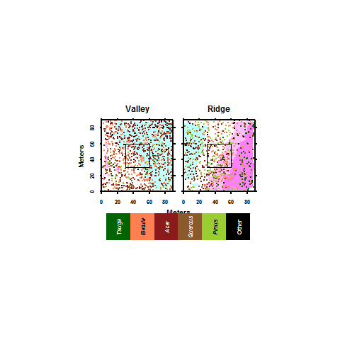

```r
# dev.off() end hemlock



# begin hardwoods

# pdf(file='hardwood_countors.pdf', width=4.75, height=6, colormodel='cmyk',
# pointsize=9)

layout(matrix(c(2, 1, 0, 0, 3, 3), 3, 2, byrow = TRUE), widths = rep(lcm(4.08),
    2), heights = c(rep(lcm(4.08), 1), lcm(0.75), lcm(1.5)))
# layout.show(3)

par(pin = c(1.75, 1.75), plt = c(0.0625, 0.9375, 0.0625, 0.9375))

filled.contour3(p.7.i, xlim = c(0, 90), ylim = c(0, 90), axes = FALSE, nlevels = 5)

for (i in 1:length(genera)) {
    points(plot.7$xcoord[plot.7$genus == genera[i]], plot.7$ycoord[plot.7$genus ==
        genera[i]], col = genera.colors.1[i], pch = 19, cex = cex.I[i])
}
axis(1, at = seq(0, 80, 20), labels = TRUE, tcl = -0.25, lwd = 2, font.axis = 2)
axis(2, at = seq(0, 80, 20), labels = FALSE, tcl = -0.25, lwd = 2, font.axis = 2)
axis(3, at = seq(0, 80, 20), labels = FALSE, tcl = -0.25, lwd = 2)
axis(4, at = seq(0, 80, 20), labels = FALSE, tcl = -0.25, lwd = 2)
box(lwd = 2)
rect(30, 30, 60, 60, border = "black", lty = "solid", lwd = 1)
mtext("Meters", side = 1, font = 2, padj = 3, adj = -0.35, cex = 0.85)
mtext("Ridge", side = 3, font = 2, padj = -1, cex = 1)
filled.contour3(p.8.i, xlim = c(0, 90), ylim = c(0, 90), axes = FALSE, nlevels = 5)

for (i in 1:length(genera)) {
    points(plot.8$xcoord[plot.8$genus == genera[i]], plot.8$ycoord[plot.8$genus ==
        genera[i]], col = genera.colors.1[i], pch = 19, cex = cex.I[i])
}
axis(1, at = seq(0, 80, 20), labels = TRUE, tcl = -0.25, lwd = 2, font.axis = 2)
axis(2, at = seq(0, 80, 20), labels = TRUE, tcl = -0.25, lwd = 2, font.axis = 2)
axis(3, at = seq(0, 80, 20), labels = FALSE, tcl = -0.25, lwd = 2)
axis(4, at = seq(0, 80, 20), labels = FALSE, tcl = -0.25, lwd = 2)
box(lwd = 2)
rect(30, 30, 60, 60, border = "black", lty = "solid", lwd = 1)
mtext("Meters", side = 2, font = 2, padj = -3, cex = 0.85)
mtext("Valley", side = 3, font = 2, padj = -1, cex = 1)

genera.colors.1 <- c("firebrick4", "coral", "black", "black", "black", "black",
    "black", "black", "black", "olivedrab3", "black", "tan4", "black", "darkgreen")

genera.rank <- c(14, 2, 1, 12, 10, 7, 9, 4, 11, 8, 3, 6, 5, 13)

image(1:6, 1, as.matrix(1:6), col = genera.colors.1[genera.rank[1:6]], xlab = "",
    ylab = "", xaxt = "n", yaxt = "n", bty = "n")
blacks <- c(2, 5)
whites <- c(1, 3, 4)
for (i in whites) text(i, 1, genera[genera.rank][i], font = 4, col = "white",
    srt = 90)
for (i in blacks) text(i, 1, genera[genera.rank][i], font = 4, col = "black",
    srt = 90)
text(6, 1, "Other", font = 2, col = "white", srt = 90)

# dev.off()
```

Compute Ripley's K for each species, each plot

First, create sptaial point patterns; remove points with x or y outside of c(0,90)

```r
plot.1 <- plot.1[plot.1[, 9] >= 0 & plot.1[, 9] <= 90, ]
plot.1 <- plot.1[plot.1[, 10] >= 0 & plot.1[, 10] <= 90, ]
plot.1.pp <- ppp(plot.1[, 9], plot.1[, 10], c(0, 90), c(0, 90))
plot.2 <- plot.2[plot.2[, 9] >= 0 & plot.2[, 9] <= 90, ]
plot.2 <- plot.2[plot.2[, 10] >= 0 & plot.2[, 10] <= 90, ]
plot.2.pp <- ppp(plot.2[, 9], plot.2[, 10], c(0, 90), c(0, 90))
plot.3 <- plot.3[plot.3[, 9] >= 0 & plot.3[, 9] <= 90, ]
plot.3 <- plot.3[plot.3[, 10] >= 0 & plot.3[, 10] <= 90, ]
plot.3.pp <- ppp(plot.3[, 9], plot.3[, 10], c(0, 90), c(0, 90))
plot.4 <- plot.4[plot.4[, 9] >= 0 & plot.4[, 9] <= 90, ]
plot.4 <- plot.4[plot.4[, 10] >= 0 & plot.4[, 10] <= 90, ]
plot.4.pp <- ppp(plot.4[, 9], plot.4[, 10], c(0, 90), c(0, 90))
plot.5 <- plot.5[plot.5[, 9] >= 0 & plot.5[, 9] <= 90, ]
plot.5 <- plot.5[plot.5[, 10] >= 0 & plot.5[, 10] <= 90, ]
plot.5.pp <- ppp(plot.5[, 9], plot.5[, 10], c(0, 90), c(0, 90))
plot.6 <- plot.6[plot.6[, 9] >= 0 & plot.6[, 9] <= 90, ]
plot.6 <- plot.6[plot.6[, 10] >= 0 & plot.6[, 10] <= 90, ]
plot.6.pp <- ppp(plot.6[, 9], plot.6[, 10], c(0, 90), c(0, 90))
plot.7 <- plot.7[plot.7[, 9] >= 0 & plot.7[, 9] <= 90, ]
plot.7 <- plot.7[plot.7[, 10] >= 0 & plot.7[, 10] <= 90, ]
plot.7.pp <- ppp(plot.7[, 9], plot.7[, 10], c(0, 90), c(0, 90))
plot.8 <- plot.8[plot.8[, 9] >= 0 & plot.8[, 9] <= 90, ]
plot.8 <- plot.8[plot.8[, 10] >= 0 & plot.8[, 10] <= 90, ]
plot.8.pp <- ppp(plot.8[, 9], plot.8[, 10], c(0, 90), c(0, 90))
```

Now, plot, generate contours, and Kobs vs Ktheor

```r
par(mfrow = c(5, 3), pin = c(1.75, 1.75), plt = c(0.0625, 0.9375, 0.0625, 0.9375))


plot(plot.1.pp[plot.1$genus == "Tsuga"])
plot(density(plot.1.pp[plot.1$genus == "Tsuga"]))
plot(envelope(plot.1.pp[plot.1$genus == "Tsuga"], Lest, global = FALSE))
```

```
## Generating 99 simulations of CSR  ...
## 1, 2, 3, 4, 5, 6, 7, 8, 9, 10, 11, 12, 13, 14, 15,
## 16, 17, 18, 19, 20, 21, 22, 23, 24, 25, 26, 27, 28, 29, 30,
## 31, 32, 33, 34, 35, 36, 37, 38, 39, 40, 41, 42, 43, 44, 45,
## 46, 47, 48, 49, 50, 51, 52, 53, 54, 55, 56, 57, 58, 59, 60,
## 61, 62, 63, 64, 65, 66, 67, 68, 69, 70, 71, 72, 73, 74, 75,
## 76, 77, 78, 79, 80, 81, 82, 83, 84, 85, 86, 87, 88, 89, 90,
## 91, 92, 93, 94, 95, 96, 97, 98,  99.
##
## Done.
```

```
##      lty col  key      label
## obs    1   1  obs  L[obs](r)
## theo   2   2 theo L[theo](r)
## hi     1   8   hi   L[hi](r)
## lo     1   8   lo   L[lo](r)
##                                                meaning
## obs            observed value of L(r) for data pattern
## theo                 theoretical value of L(r) for CSR
## hi   upper pointwise envelope of L(r) from simulations
## lo   lower pointwise envelope of L(r) from simulations
```

```r
plot(plot.1.pp[plot.1$genus == "Betula"])
plot(density(plot.1.pp[plot.1$genus == "Betula"]))
plot(envelope(plot.1.pp[plot.1$genus == "Betula"], Kest))
```

```
## Generating 99 simulations of CSR  ...
## 1, 2, 3, 4, 5, 6, 7, 8, 9, 10, 11, 12, 13, 14, 15,
## 16, 17, 18, 19, 20, 21, 22, 23, 24, 25, 26, 27, 28, 29, 30,
## 31, 32, 33, 34, 35, 36, 37, 38, 39, 40, 41, 42, 43, 44, 45,
## 46, 47, 48, 49, 50, 51, 52, 53, 54, 55, 56, 57, 58, 59, 60,
## 61, 62, 63, 64, 65, 66, 67, 68, 69, 70, 71, 72, 73, 74, 75,
## 76, 77, 78, 79, 80, 81, 82, 83, 84, 85, 86, 87, 88, 89, 90,
## 91, 92, 93, 94, 95, 96, 97, 98,  99.
##
## Done.
```

```
##      lty col  key      label
## obs    1   1  obs  K[obs](r)
## theo   2   2 theo K[theo](r)
## hi     1   8   hi   K[hi](r)
## lo     1   8   lo   K[lo](r)
##                                                meaning
## obs            observed value of K(r) for data pattern
## theo                 theoretical value of K(r) for CSR
## hi   upper pointwise envelope of K(r) from simulations
## lo   lower pointwise envelope of K(r) from simulations
```

```r
plot(plot.1.pp[plot.1$genus == "Quercus"])
plot(density(plot.1.pp[plot.1$genus == "Quercus"]))
plot(envelope(plot.1.pp[plot.1$genus == "Quercus"], Kest))
```

```
## Generating 99 simulations of CSR  ...
## 1, 2, 3, 4, 5, 6, 7, 8, 9, 10, 11, 12, 13, 14, 15,
## 16, 17, 18, 19, 20, 21, 22, 23, 24, 25, 26, 27, 28, 29, 30,
## 31, 32, 33, 34, 35, 36, 37, 38, 39, 40, 41, 42, 43, 44, 45,
## 46, 47, 48, 49, 50, 51, 52, 53, 54, 55, 56, 57, 58, 59, 60,
## 61, 62, 63, 64, 65, 66, 67, 68, 69, 70, 71, 72, 73, 74, 75,
## 76, 77, 78, 79, 80, 81, 82, 83, 84, 85, 86, 87, 88, 89, 90,
## 91, 92, 93, 94, 95, 96, 97, 98,  99.
##
## Done.
```

```
##      lty col  key      label
## obs    1   1  obs  K[obs](r)
## theo   2   2 theo K[theo](r)
## hi     1   8   hi   K[hi](r)
## lo     1   8   lo   K[lo](r)
##                                                meaning
## obs            observed value of K(r) for data pattern
## theo                 theoretical value of K(r) for CSR
## hi   upper pointwise envelope of K(r) from simulations
## lo   lower pointwise envelope of K(r) from simulations
```

```r
plot(plot.1.pp[plot.1$genus == "Acer"])
plot(density(plot.1.pp[plot.1$genus == "Acer"]))
plot(envelope(plot.1.pp[plot.1$genus == "Acer"], Kest))
```

```
## Generating 99 simulations of CSR  ...
## 1, 2, 3, 4, 5, 6, 7, 8, 9, 10, 11, 12, 13, 14, 15,
## 16, 17, 18, 19, 20, 21, 22, 23, 24, 25, 26, 27, 28, 29, 30,
## 31, 32, 33, 34, 35, 36, 37, 38, 39, 40, 41, 42, 43, 44, 45,
## 46, 47, 48, 49, 50, 51, 52, 53, 54, 55, 56, 57, 58, 59, 60,
## 61, 62, 63, 64, 65, 66, 67, 68, 69, 70, 71, 72, 73, 74, 75,
## 76, 77, 78, 79, 80, 81, 82, 83, 84, 85, 86, 87, 88, 89, 90,
## 91, 92, 93, 94, 95, 96, 97, 98,  99.
##
## Done.
```

```
##      lty col  key      label
## obs    1   1  obs  K[obs](r)
## theo   2   2 theo K[theo](r)
## hi     1   8   hi   K[hi](r)
## lo     1   8   lo   K[lo](r)
##                                                meaning
## obs            observed value of K(r) for data pattern
## theo                 theoretical value of K(r) for CSR
## hi   upper pointwise envelope of K(r) from simulations
## lo   lower pointwise envelope of K(r) from simulations
```

```
## Generating 99 simulations of CSR  ...
## 1, 2, 3, 4, 5, 6, 7, 8, 9, 10, 11, 12, 13, 14, 15,
## 16, 17, 18, 19, 20, 21, 22, 23, 24, 25, 26, 27, 28, 29, 30,
## 31, 32, 33, 34, 35, 36, 37, 38, 39, 40, 41, 42, 43, 44, 45,
## 46, 47, 48, 49, 50, 51, 52, 53, 54, 55, 56, 57, 58, 59, 60,
## 61, 62, 63, 64, 65, 66, 67, 68, 69, 70, 71, 72, 73, 74, 75,
## 76, 77, 78, 79, 80, 81, 82, 83, 84, 85, 86, 87, 88, 89, 90,
## 91, 92, 93, 94, 95, 96, 97, 98,  99.
##
## Done.
```

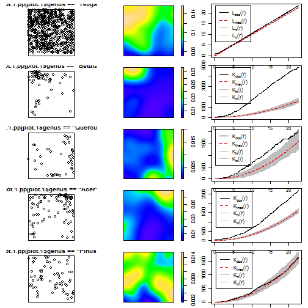

```
##      lty col  key      label
## obs    1   1  obs  K[obs](r)
## theo   2   2 theo K[theo](r)
## hi     1   8   hi   K[hi](r)
## lo     1   8   lo   K[lo](r)
##                                                meaning
## obs            observed value of K(r) for data pattern
## theo                 theoretical value of K(r) for CSR
## hi   upper pointwise envelope of K(r) from simulations
## lo   lower pointwise envelope of K(r) from simulations
```

```r
plot(plot.1.pp[plot.1$genus == "Pinus"])
plot(density(plot.1.pp[plot.1$genus == "Pinus"]))
plot(envelope(plot.1.pp[plot.1$genus == "Pinus"], Kest))
```

```r
par(mfrow = c(5, 3), pin = c(1.75, 1.75), plt = c(0.0625, 0.9375, 0.0625, 0.9375))
plot(plot.2.pp[plot.2$genus == "Tsuga"])
plot(density(plot.2.pp[plot.2$genus == "Tsuga"]))
plot(envelope(plot.2.pp[plot.2$genus == "Tsuga"], Kest))
```

```
## Generating 99 simulations of CSR  ...
## 1, 2, 3, 4, 5, 6, 7, 8, 9, 10, 11, 12, 13, 14, 15,
## 16, 17, 18, 19, 20, 21, 22, 23, 24, 25, 26, 27, 28, 29, 30,
## 31, 32, 33, 34, 35, 36, 37, 38, 39, 40, 41, 42, 43, 44, 45,
## 46, 47, 48, 49, 50, 51, 52, 53, 54, 55, 56, 57, 58, 59, 60,
## 61, 62, 63, 64, 65, 66, 67, 68, 69, 70, 71, 72, 73, 74, 75,
## 76, 77, 78, 79, 80, 81, 82, 83, 84, 85, 86, 87, 88, 89, 90,
## 91, 92, 93, 94, 95, 96, 97, 98,  99.
##
## Done.
```

```
##      lty col  key      label
## obs    1   1  obs  K[obs](r)
## theo   2   2 theo K[theo](r)
## hi     1   8   hi   K[hi](r)
## lo     1   8   lo   K[lo](r)
##                                                meaning
## obs            observed value of K(r) for data pattern
## theo                 theoretical value of K(r) for CSR
## hi   upper pointwise envelope of K(r) from simulations
## lo   lower pointwise envelope of K(r) from simulations
```

```r
plot(plot.2.pp[plot.2$genus == "Betula"])
plot(density(plot.2.pp[plot.2$genus == "Betula"]))
plot(envelope(plot.2.pp[plot.2$genus == "Betula"], Kest))
```

```
## Generating 99 simulations of CSR  ...
## 1, 2, 3, 4, 5, 6, 7, 8, 9, 10, 11, 12, 13, 14, 15,
## 16, 17, 18, 19, 20, 21, 22, 23, 24, 25, 26, 27, 28, 29, 30,
## 31, 32, 33, 34, 35, 36, 37, 38, 39, 40, 41, 42, 43, 44, 45,
## 46, 47, 48, 49, 50, 51, 52, 53, 54, 55, 56, 57, 58, 59, 60,
## 61, 62, 63, 64, 65, 66, 67, 68, 69, 70, 71, 72, 73, 74, 75,
## 76, 77, 78, 79, 80, 81, 82, 83, 84, 85, 86, 87, 88, 89, 90,
## 91, 92, 93, 94, 95, 96, 97, 98,  99.
##
## Done.
```

```
##      lty col  key      label
## obs    1   1  obs  K[obs](r)
## theo   2   2 theo K[theo](r)
## hi     1   8   hi   K[hi](r)
## lo     1   8   lo   K[lo](r)
##                                                meaning
## obs            observed value of K(r) for data pattern
## theo                 theoretical value of K(r) for CSR
## hi   upper pointwise envelope of K(r) from simulations
## lo   lower pointwise envelope of K(r) from simulations
```

```r
plot(plot.2.pp[plot.2$genus == "Quercus"])
plot(density(plot.2.pp[plot.2$genus == "Quercus"]))
plot(envelope(plot.2.pp[plot.2$genus == "Quercus"], Kest))
```

```
## Generating 99 simulations of CSR  ...
## 1, 2, 3, 4, 5, 6, 7, 8, 9, 10, 11, 12, 13, 14, 15,
## 16, 17, 18, 19, 20, 21, 22, 23, 24, 25, 26, 27, 28, 29, 30,
## 31, 32, 33, 34, 35, 36, 37, 38, 39, 40, 41, 42, 43, 44, 45,
## 46, 47, 48, 49, 50, 51, 52, 53, 54, 55, 56, 57, 58, 59, 60,
## 61, 62, 63, 64, 65, 66, 67, 68, 69, 70, 71, 72, 73, 74, 75,
## 76, 77, 78, 79, 80, 81, 82, 83, 84, 85, 86, 87, 88, 89, 90,
## 91, 92, 93, 94, 95, 96, 97, 98,  99.
##
## Done.
```

```
##      lty col  key      label
## obs    1   1  obs  K[obs](r)
## theo   2   2 theo K[theo](r)
## hi     1   8   hi   K[hi](r)
## lo     1   8   lo   K[lo](r)
##                                                meaning
## obs            observed value of K(r) for data pattern
## theo                 theoretical value of K(r) for CSR
## hi   upper pointwise envelope of K(r) from simulations
## lo   lower pointwise envelope of K(r) from simulations
```

```r
plot(plot.2.pp[plot.2$genus == "Acer"])
plot(density(plot.2.pp[plot.2$genus == "Acer"]))
plot(envelope(plot.2.pp[plot.2$genus == "Acer"], Kest))
```

```
## Generating 99 simulations of CSR  ...
## 1, 2, 3, 4, 5, 6, 7, 8, 9, 10, 11, 12, 13, 14, 15,
## 16, 17, 18, 19, 20, 21, 22, 23, 24, 25, 26, 27, 28, 29, 30,
## 31, 32, 33, 34, 35, 36, 37, 38, 39, 40, 41, 42, 43, 44, 45,
## 46, 47, 48, 49, 50, 51, 52, 53, 54, 55, 56, 57, 58, 59, 60,
## 61, 62, 63, 64, 65, 66, 67, 68, 69, 70, 71, 72, 73, 74, 75,
## 76, 77, 78, 79, 80, 81, 82, 83, 84, 85, 86, 87, 88, 89, 90,
## 91, 92, 93, 94, 95, 96, 97, 98,  99.
##
## Done.
```

```
##      lty col  key      label
## obs    1   1  obs  K[obs](r)
## theo   2   2 theo K[theo](r)
## hi     1   8   hi   K[hi](r)
## lo     1   8   lo   K[lo](r)
##                                                meaning
## obs            observed value of K(r) for data pattern
## theo                 theoretical value of K(r) for CSR
## hi   upper pointwise envelope of K(r) from simulations
## lo   lower pointwise envelope of K(r) from simulations
```

```
## Generating 99 simulations of CSR  ...
## 1, 2, 3, 4, 5, 6, 7, 8, 9, 10, 11, 12, 13, 14, 15,
## 16, 17, 18, 19, 20, 21, 22, 23, 24, 25, 26, 27, 28, 29, 30,
## 31, 32, 33, 34, 35, 36, 37, 38, 39, 40, 41, 42, 43, 44, 45,
## 46, 47, 48, 49, 50, 51, 52, 53, 54, 55, 56, 57, 58, 59, 60,
## 61, 62, 63, 64, 65, 66, 67, 68, 69, 70, 71, 72, 73, 74, 75,
## 76, 77, 78, 79, 80, 81, 82, 83, 84, 85, 86, 87, 88, 89, 90,
## 91, 92, 93, 94, 95, 96, 97, 98,  99.
##
## Done.
```

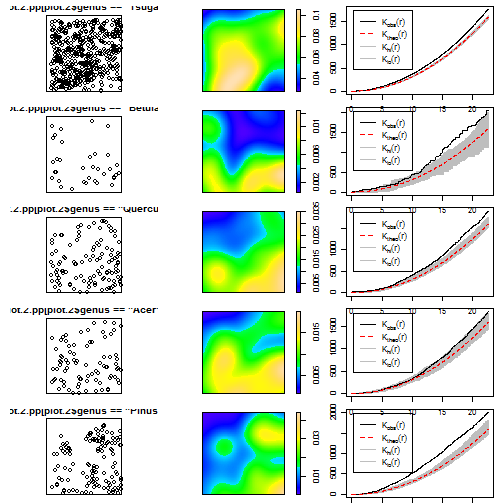

```
##      lty col  key      label
## obs    1   1  obs  K[obs](r)
## theo   2   2 theo K[theo](r)
## hi     1   8   hi   K[hi](r)
## lo     1   8   lo   K[lo](r)
##                                                meaning
## obs            observed value of K(r) for data pattern
## theo                 theoretical value of K(r) for CSR
## hi   upper pointwise envelope of K(r) from simulations
## lo   lower pointwise envelope of K(r) from simulations
```

```r
plot(plot.2.pp[plot.2$genus == "Pinus"])
plot(density(plot.2.pp[plot.2$genus == "Pinus"]))
plot(envelope(plot.2.pp[plot.2$genus == "Pinus"], Kest))
```

```r
par(mfrow = c(5, 3), pin = c(1.75, 1.75), plt = c(0.0625, 0.9375, 0.0625, 0.9375))
plot(plot.3.pp[plot.3$genus == "Tsuga"])
plot(density(plot.3.pp[plot.3$genus == "Tsuga"]))
plot(envelope(plot.3.pp[plot.3$genus == "Tsuga"], Kest))
```

```
## Generating 99 simulations of CSR  ...
## 1, 2, 3, 4, 5, 6, 7, 8, 9, 10, 11, 12, 13, 14, 15,
## 16, 17, 18, 19, 20, 21, 22, 23, 24, 25, 26, 27, 28, 29, 30,
## 31, 32, 33, 34, 35, 36, 37, 38, 39, 40, 41, 42, 43, 44, 45,
## 46, 47, 48, 49, 50, 51, 52, 53, 54, 55, 56, 57, 58, 59, 60,
## 61, 62, 63, 64, 65, 66, 67, 68, 69, 70, 71, 72, 73, 74, 75,
## 76, 77, 78, 79, 80, 81, 82, 83, 84, 85, 86, 87, 88, 89, 90,
## 91, 92, 93, 94, 95, 96, 97, 98,  99.
##
## Done.
```

```
##      lty col  key      label
## obs    1   1  obs  K[obs](r)
## theo   2   2 theo K[theo](r)
## hi     1   8   hi   K[hi](r)
## lo     1   8   lo   K[lo](r)
##                                                meaning
## obs            observed value of K(r) for data pattern
## theo                 theoretical value of K(r) for CSR
## hi   upper pointwise envelope of K(r) from simulations
## lo   lower pointwise envelope of K(r) from simulations
```

```r
plot(plot.3.pp[plot.3$genus == "Betula"])
plot(density(plot.3.pp[plot.3$genus == "Betula"]))
plot(envelope(plot.3.pp[plot.3$genus == "Betula"], Kest))
```

```
## Generating 99 simulations of CSR  ...
## 1, 2, 3, 4, 5, 6, 7, 8, 9, 10, 11, 12, 13, 14, 15,
## 16, 17, 18, 19, 20, 21, 22, 23, 24, 25, 26, 27, 28, 29, 30,
## 31, 32, 33, 34, 35, 36, 37, 38, 39, 40, 41, 42, 43, 44, 45,
## 46, 47, 48, 49, 50, 51, 52, 53, 54, 55, 56, 57, 58, 59, 60,
## 61, 62, 63, 64, 65, 66, 67, 68, 69, 70, 71, 72, 73, 74, 75,
## 76, 77, 78, 79, 80, 81, 82, 83, 84, 85, 86, 87, 88, 89, 90,
## 91, 92, 93, 94, 95, 96, 97, 98,  99.
##
## Done.
```

```
##      lty col  key      label
## obs    1   1  obs  K[obs](r)
## theo   2   2 theo K[theo](r)
## hi     1   8   hi   K[hi](r)
## lo     1   8   lo   K[lo](r)
##                                                meaning
## obs            observed value of K(r) for data pattern
## theo                 theoretical value of K(r) for CSR
## hi   upper pointwise envelope of K(r) from simulations
## lo   lower pointwise envelope of K(r) from simulations
```

```r
plot(plot.3.pp[plot.3$genus == "Quercus"])
plot(density(plot.3.pp[plot.3$genus == "Quercus"]))
plot(envelope(plot.3.pp[plot.3$genus == "Quercus"], Kest))
```

```
## Generating 99 simulations of CSR  ...
## 1, 2, 3, 4, 5, 6, 7, 8, 9, 10, 11, 12, 13, 14, 15,
## 16, 17, 18, 19, 20, 21, 22, 23, 24, 25, 26, 27, 28, 29, 30,
## 31, 32, 33, 34, 35, 36, 37, 38, 39, 40, 41, 42, 43, 44, 45,
## 46, 47, 48, 49, 50, 51, 52, 53, 54, 55, 56, 57, 58, 59, 60,
## 61, 62, 63, 64, 65, 66, 67, 68, 69, 70, 71, 72, 73, 74, 75,
## 76, 77, 78, 79, 80, 81, 82, 83, 84, 85, 86, 87, 88, 89, 90,
## 91, 92, 93, 94, 95, 96, 97, 98,  99.
##
## Done.
```

```
##      lty col  key      label
## obs    1   1  obs  K[obs](r)
## theo   2   2 theo K[theo](r)
## hi     1   8   hi   K[hi](r)
## lo     1   8   lo   K[lo](r)
##                                                meaning
## obs            observed value of K(r) for data pattern
## theo                 theoretical value of K(r) for CSR
## hi   upper pointwise envelope of K(r) from simulations
## lo   lower pointwise envelope of K(r) from simulations
```

```r
plot(plot.3.pp[plot.3$genus == "Acer"])
plot(density(plot.3.pp[plot.3$genus == "Acer"]))
plot(envelope(plot.3.pp[plot.3$genus == "Acer"], Kest))
```

```
## Generating 99 simulations of CSR  ...
## 1, 2, 3, 4, 5, 6, 7, 8, 9, 10, 11, 12, 13, 14, 15,
## 16, 17, 18, 19, 20, 21, 22, 23, 24, 25, 26, 27, 28, 29, 30,
## 31, 32, 33, 34, 35, 36, 37, 38, 39, 40, 41, 42, 43, 44, 45,
## 46, 47, 48, 49, 50, 51, 52, 53, 54, 55, 56, 57, 58, 59, 60,
## 61, 62, 63, 64, 65, 66, 67, 68, 69, 70, 71, 72, 73, 74, 75,
## 76, 77, 78, 79, 80, 81, 82, 83, 84, 85, 86, 87, 88, 89, 90,
## 91, 92, 93, 94, 95, 96, 97, 98,  99.
##
## Done.
```

```
##      lty col  key      label
## obs    1   1  obs  K[obs](r)
## theo   2   2 theo K[theo](r)
## hi     1   8   hi   K[hi](r)
## lo     1   8   lo   K[lo](r)
##                                                meaning
## obs            observed value of K(r) for data pattern
## theo                 theoretical value of K(r) for CSR
## hi   upper pointwise envelope of K(r) from simulations
## lo   lower pointwise envelope of K(r) from simulations
```

```
## Generating 99 simulations of CSR  ...
## 1, 2, 3, 4, 5, 6, 7, 8, 9, 10, 11, 12, 13, 14, 15,
## 16, 17, 18, 19, 20, 21, 22, 23, 24, 25, 26, 27, 28, 29, 30,
## 31, 32, 33, 34, 35, 36, 37, 38, 39, 40, 41, 42, 43, 44, 45,
## 46, 47, 48, 49, 50, 51, 52, 53, 54, 55, 56, 57, 58, 59, 60,
## 61, 62, 63, 64, 65, 66, 67, 68, 69, 70, 71, 72, 73, 74, 75,
## 76, 77, 78, 79, 80, 81, 82, 83, 84, 85, 86, 87, 88, 89, 90,
## 91, 92, 93, 94, 95, 96, 97, 98,  99.
##
## Done.
```

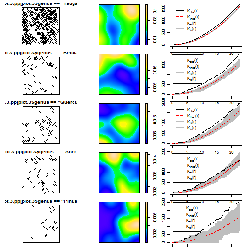

```
##      lty col  key      label
## obs    1   1  obs  K[obs](r)
## theo   2   2 theo K[theo](r)
## hi     1   8   hi   K[hi](r)
## lo     1   8   lo   K[lo](r)
##                                                meaning
## obs            observed value of K(r) for data pattern
## theo                 theoretical value of K(r) for CSR
## hi   upper pointwise envelope of K(r) from simulations
## lo   lower pointwise envelope of K(r) from simulations
```

```r
plot(plot.3.pp[plot.3$genus == "Pinus"])
plot(density(plot.3.pp[plot.3$genus == "Pinus"]))
plot(envelope(plot.3.pp[plot.3$genus == "Pinus"], Kest))
```

```r
par(mfrow = c(5, 3), pin = c(1.75, 1.75), plt = c(0.0625, 0.9375, 0.0625, 0.9375))
plot(plot.4.pp[plot.4$genus == "Tsuga"])
plot(density(plot.4.pp[plot.4$genus == "Tsuga"]))
plot(envelope(plot.4.pp[plot.4$genus == "Tsuga"], Kest))
```

```
## Generating 99 simulations of CSR  ...
## 1, 2, 3, 4, 5, 6, 7, 8, 9, 10, 11, 12, 13, 14, 15,
## 16, 17, 18, 19, 20, 21, 22, 23, 24, 25, 26, 27, 28, 29, 30,
## 31, 32, 33, 34, 35, 36, 37, 38, 39, 40, 41, 42, 43, 44, 45,
## 46, 47, 48, 49, 50, 51, 52, 53, 54, 55, 56, 57, 58, 59, 60,
## 61, 62, 63, 64, 65, 66, 67, 68, 69, 70, 71, 72, 73, 74, 75,
## 76, 77, 78, 79, 80, 81, 82, 83, 84, 85, 86, 87, 88, 89, 90,
## 91, 92, 93, 94, 95, 96, 97, 98,  99.
##
## Done.
```

```
##      lty col  key      label
## obs    1   1  obs  K[obs](r)
## theo   2   2 theo K[theo](r)
## hi     1   8   hi   K[hi](r)
## lo     1   8   lo   K[lo](r)
##                                                meaning
## obs            observed value of K(r) for data pattern
## theo                 theoretical value of K(r) for CSR
## hi   upper pointwise envelope of K(r) from simulations
## lo   lower pointwise envelope of K(r) from simulations
```

```r
plot(plot.4.pp[plot.4$genus == "Betula"])
plot(density(plot.4.pp[plot.4$genus == "Betula"]))
plot(envelope(plot.4.pp[plot.4$genus == "Betula"], Kest))
```

```
## Generating 99 simulations of CSR  ...
## 1, 2, 3, 4, 5, 6, 7, 8, 9, 10, 11, 12, 13, 14, 15,
## 16, 17, 18, 19, 20, 21, 22, 23, 24, 25, 26, 27, 28, 29, 30,
## 31, 32, 33, 34, 35, 36, 37, 38, 39, 40, 41, 42, 43, 44, 45,
## 46, 47, 48, 49, 50, 51, 52, 53, 54, 55, 56, 57, 58, 59, 60,
## 61, 62, 63, 64, 65, 66, 67, 68, 69, 70, 71, 72, 73, 74, 75,
## 76, 77, 78, 79, 80, 81, 82, 83, 84, 85, 86, 87, 88, 89, 90,
## 91, 92, 93, 94, 95, 96, 97, 98,  99.
##
## Done.
```

```
##      lty col  key      label
## obs    1   1  obs  K[obs](r)
## theo   2   2 theo K[theo](r)
## hi     1   8   hi   K[hi](r)
## lo     1   8   lo   K[lo](r)
##                                                meaning
## obs            observed value of K(r) for data pattern
## theo                 theoretical value of K(r) for CSR
## hi   upper pointwise envelope of K(r) from simulations
## lo   lower pointwise envelope of K(r) from simulations
```

```r
plot(plot.4.pp[plot.4$genus == "Quercus"])
plot(density(plot.4.pp[plot.4$genus == "Quercus"]))
plot(envelope(plot.4.pp[plot.4$genus == "Quercus"], Kest))
```

```
## Generating 99 simulations of CSR  ...
## 1, 2, 3, 4, 5, 6, 7, 8, 9, 10, 11, 12, 13, 14, 15,
## 16, 17, 18, 19, 20, 21, 22, 23, 24, 25, 26, 27, 28, 29, 30,
## 31, 32, 33, 34, 35, 36, 37, 38, 39, 40, 41, 42, 43, 44, 45,
## 46, 47, 48, 49, 50, 51, 52, 53, 54, 55, 56, 57, 58, 59, 60,
## 61, 62, 63, 64, 65, 66, 67, 68, 69, 70, 71, 72, 73, 74, 75,
## 76, 77, 78, 79, 80, 81, 82, 83, 84, 85, 86, 87, 88, 89, 90,
## 91, 92, 93, 94, 95, 96, 97, 98,  99.
##
## Done.
```

```
##      lty col  key      label
## obs    1   1  obs  K[obs](r)
## theo   2   2 theo K[theo](r)
## hi     1   8   hi   K[hi](r)
## lo     1   8   lo   K[lo](r)
##                                                meaning
## obs            observed value of K(r) for data pattern
## theo                 theoretical value of K(r) for CSR
## hi   upper pointwise envelope of K(r) from simulations
## lo   lower pointwise envelope of K(r) from simulations
```

```r
plot(plot.4.pp[plot.4$genus == "Acer"])
plot(density(plot.4.pp[plot.4$genus == "Acer"]))
plot(envelope(plot.4.pp[plot.4$genus == "Acer"], Kest))
```

```
## Generating 99 simulations of CSR  ...
## 1, 2, 3, 4, 5, 6, 7, 8, 9, 10, 11, 12, 13, 14, 15,
## 16, 17, 18, 19, 20, 21, 22, 23, 24, 25, 26, 27, 28, 29, 30,
## 31, 32, 33, 34, 35, 36, 37, 38, 39, 40, 41, 42, 43, 44, 45,
## 46, 47, 48, 49, 50, 51, 52, 53, 54, 55, 56, 57, 58, 59, 60,
## 61, 62, 63, 64, 65, 66, 67, 68, 69, 70, 71, 72, 73, 74, 75,
## 76, 77, 78, 79, 80, 81, 82, 83, 84, 85, 86, 87, 88, 89, 90,
## 91, 92, 93, 94, 95, 96, 97, 98,  99.
##
## Done.
```

```
##      lty col  key      label
## obs    1   1  obs  K[obs](r)
## theo   2   2 theo K[theo](r)
## hi     1   8   hi   K[hi](r)
## lo     1   8   lo   K[lo](r)
##                                                meaning
## obs            observed value of K(r) for data pattern
## theo                 theoretical value of K(r) for CSR
## hi   upper pointwise envelope of K(r) from simulations
## lo   lower pointwise envelope of K(r) from simulations
```

```
## Generating 99 simulations of CSR  ...
## 1, 2, 3, 4, 5, 6, 7, 8, 9, 10, 11, 12, 13, 14, 15,
## 16, 17, 18, 19, 20, 21, 22, 23, 24, 25, 26, 27, 28, 29, 30,
## 31, 32, 33, 34, 35, 36, 37, 38, 39, 40, 41, 42, 43, 44, 45,
## 46, 47, 48, 49, 50, 51, 52, 53, 54, 55, 56, 57, 58, 59, 60,
## 61, 62, 63, 64, 65, 66, 67, 68, 69, 70, 71, 72, 73, 74, 75,
## 76, 77, 78, 79, 80, 81, 82, 83, 84, 85, 86, 87, 88, 89, 90,
## 91, 92, 93, 94, 95, 96, 97, 98,  99.
##
## Done.
```

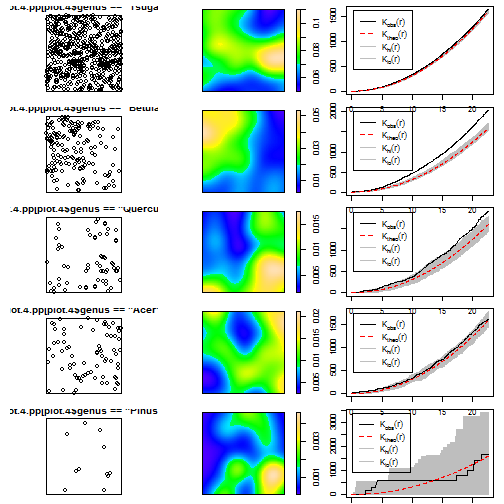

```
##      lty col  key      label
## obs    1   1  obs  K[obs](r)
## theo   2   2 theo K[theo](r)
## hi     1   8   hi   K[hi](r)
## lo     1   8   lo   K[lo](r)
##                                                meaning
## obs            observed value of K(r) for data pattern
## theo                 theoretical value of K(r) for CSR
## hi   upper pointwise envelope of K(r) from simulations
## lo   lower pointwise envelope of K(r) from simulations
```

```r
plot(plot.4.pp[plot.4$genus == "Pinus"])
plot(density(plot.4.pp[plot.4$genus == "Pinus"]))
plot(envelope(plot.4.pp[plot.4$genus == "Pinus"], Kest))
```

```r
plot(plot.5.pp[plot.5$genus == "Tsuga"])
plot(density(plot.5.pp[plot.5$genus == "Tsuga"]))
plot(envelope(plot.5.pp[plot.5$genus == "Tsuga"], Kest))
```

```
## Generating 99 simulations of CSR  ...
## 1, 2, 3, 4, 5, 6, 7, 8, 9, 10, 11, 12, 13, 14, 15,
## 16, 17, 18, 19, 20, 21, 22, 23, 24, 25, 26, 27, 28, 29, 30,
## 31, 32, 33, 34, 35, 36, 37, 38, 39, 40, 41, 42, 43, 44, 45,
## 46, 47, 48, 49, 50, 51, 52, 53, 54, 55, 56, 57, 58, 59, 60,
## 61, 62, 63, 64, 65, 66, 67, 68, 69, 70, 71, 72, 73, 74, 75,
## 76, 77, 78, 79, 80, 81, 82, 83, 84, 85, 86, 87, 88, 89, 90,
## 91, 92, 93, 94, 95, 96, 97, 98,  99.
##
## Done.
```

```
##      lty col  key      label
## obs    1   1  obs  K[obs](r)
## theo   2   2 theo K[theo](r)
## hi     1   8   hi   K[hi](r)
## lo     1   8   lo   K[lo](r)
##                                                meaning
## obs            observed value of K(r) for data pattern
## theo                 theoretical value of K(r) for CSR
## hi   upper pointwise envelope of K(r) from simulations
## lo   lower pointwise envelope of K(r) from simulations
```

```r
plot(plot.5.pp[plot.5$genus == "Betula"])
plot(density(plot.5.pp[plot.5$genus == "Betula"]))
plot(envelope(plot.5.pp[plot.5$genus == "Betula"], Kest))
```

```
## Generating 99 simulations of CSR  ...
## 1, 2, 3, 4, 5, 6, 7, 8, 9, 10, 11, 12, 13, 14, 15,
## 16, 17, 18, 19, 20, 21, 22, 23, 24, 25, 26, 27, 28, 29, 30,
## 31, 32, 33, 34, 35, 36, 37, 38, 39, 40, 41, 42, 43, 44, 45,
## 46, 47, 48, 49, 50, 51, 52, 53, 54, 55, 56, 57, 58, 59, 60,
## 61, 62, 63, 64, 65, 66, 67, 68, 69, 70, 71, 72, 73, 74, 75,
## 76, 77, 78, 79, 80, 81, 82, 83, 84, 85, 86, 87, 88, 89, 90,
## 91, 92, 93, 94, 95, 96, 97, 98,  99.
##
## Done.
```

```
##      lty col  key      label
## obs    1   1  obs  K[obs](r)
## theo   2   2 theo K[theo](r)
## hi     1   8   hi   K[hi](r)
## lo     1   8   lo   K[lo](r)
##                                                meaning
## obs            observed value of K(r) for data pattern
## theo                 theoretical value of K(r) for CSR
## hi   upper pointwise envelope of K(r) from simulations
## lo   lower pointwise envelope of K(r) from simulations
```

```r
plot(plot.5.pp[plot.5$genus == "Quercus"])
plot(density(plot.5.pp[plot.5$genus == "Quercus"]))
plot(envelope(plot.5.pp[plot.5$genus == "Quercus"], Kest))
```

```
## Generating 99 simulations of CSR  ...
## 1, 2, 3, 4, 5, 6, 7, 8, 9, 10, 11, 12, 13, 14, 15,
## 16, 17, 18, 19, 20, 21, 22, 23, 24, 25, 26, 27, 28, 29, 30,
## 31, 32, 33, 34, 35, 36, 37, 38, 39, 40, 41, 42, 43, 44, 45,
## 46, 47, 48, 49, 50, 51, 52, 53, 54, 55, 56, 57, 58, 59, 60,
## 61, 62, 63, 64, 65, 66, 67, 68, 69, 70, 71, 72, 73, 74, 75,
## 76, 77, 78, 79, 80, 81, 82, 83, 84, 85, 86, 87, 88, 89, 90,
## 91, 92, 93, 94, 95, 96, 97, 98,  99.
##
## Done.
```

```
##      lty col  key      label
## obs    1   1  obs  K[obs](r)
## theo   2   2 theo K[theo](r)
## hi     1   8   hi   K[hi](r)
## lo     1   8   lo   K[lo](r)
##                                                meaning
## obs            observed value of K(r) for data pattern
## theo                 theoretical value of K(r) for CSR
## hi   upper pointwise envelope of K(r) from simulations
## lo   lower pointwise envelope of K(r) from simulations
```

```r
plot(plot.5.pp[plot.5$genus == "Acer"])
plot(density(plot.5.pp[plot.5$genus == "Acer"]))
plot(envelope(plot.5.pp[plot.5$genus == "Acer"], Kest))
```

```
## Generating 99 simulations of CSR  ...
## 1, 2, 3, 4, 5, 6, 7, 8, 9, 10, 11, 12, 13, 14, 15,
## 16, 17, 18, 19, 20, 21, 22, 23, 24, 25, 26, 27, 28, 29, 30,
## 31, 32, 33, 34, 35, 36, 37, 38, 39, 40, 41, 42, 43, 44, 45,
## 46, 47, 48, 49, 50, 51, 52, 53, 54, 55, 56, 57, 58, 59, 60,
## 61, 62, 63, 64, 65, 66, 67, 68, 69, 70, 71, 72, 73, 74, 75,
## 76, 77, 78, 79, 80, 81, 82, 83, 84, 85, 86, 87, 88, 89, 90,
## 91, 92, 93, 94, 95, 96, 97, 98,  99.
##
## Done.
```

```
##      lty col  key      label
## obs    1   1  obs  K[obs](r)
## theo   2   2 theo K[theo](r)
## hi     1   8   hi   K[hi](r)
## lo     1   8   lo   K[lo](r)
##                                                meaning
## obs            observed value of K(r) for data pattern
## theo                 theoretical value of K(r) for CSR
## hi   upper pointwise envelope of K(r) from simulations
## lo   lower pointwise envelope of K(r) from simulations
```

```
## Generating 99 simulations of CSR  ...
## 1, 2, 3, 4, 5, 6, 7, 8, 9, 10, 11, 12, 13, 14, 15,
## 16, 17, 18, 19, 20, 21, 22, 23, 24, 25, 26, 27, 28, 29, 30,
## 31, 32, 33, 34, 35, 36, 37, 38, 39, 40, 41, 42, 43, 44, 45,
## 46, 47, 48, 49, 50, 51, 52, 53, 54, 55, 56, 57, 58, 59, 60,
## 61, 62, 63, 64, 65, 66, 67, 68, 69, 70, 71, 72, 73, 74, 75,
## 76, 77, 78, 79, 80, 81, 82, 83, 84, 85, 86, 87, 88, 89, 90,
## 91, 92, 93, 94, 95, 96, 97, 98,  99.
##
## Done.
```

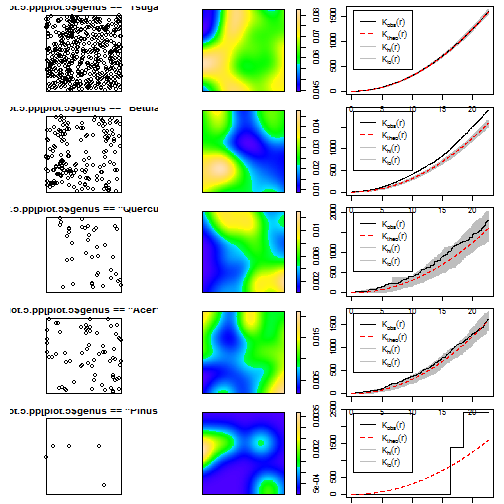

```
##      lty col  key      label
## obs    1   1  obs  K[obs](r)
## theo   2   2 theo K[theo](r)
## hi     1   8   hi   K[hi](r)
## lo     1   8   lo   K[lo](r)
##                                                meaning
## obs            observed value of K(r) for data pattern
## theo                 theoretical value of K(r) for CSR
## hi   upper pointwise envelope of K(r) from simulations
## lo   lower pointwise envelope of K(r) from simulations
```

```r
plot(plot.5.pp[plot.5$genus == "Pinus"])
plot(density(plot.5.pp[plot.5$genus == "Pinus"]))
plot(envelope(plot.5.pp[plot.5$genus == "Pinus"], Kest))
```

```r
plot(plot.6.pp[plot.6$genus == "Tsuga"])
plot(density(plot.6.pp[plot.6$genus == "Tsuga"]))
plot(envelope(plot.6.pp[plot.6$genus == "Tsuga"], Kest))
```

```
## Generating 99 simulations of CSR  ...
## 1, 2, 3, 4, 5, 6, 7, 8, 9, 10, 11, 12, 13, 14, 15,
## 16, 17, 18, 19, 20, 21, 22, 23, 24, 25, 26, 27, 28, 29, 30,
## 31, 32, 33, 34, 35, 36, 37, 38, 39, 40, 41, 42, 43, 44, 45,
## 46, 47, 48, 49, 50, 51, 52, 53, 54, 55, 56, 57, 58, 59, 60,
## 61, 62, 63, 64, 65, 66, 67, 68, 69, 70, 71, 72, 73, 74, 75,
## 76, 77, 78, 79, 80, 81, 82, 83, 84, 85, 86, 87, 88, 89, 90,
## 91, 92, 93, 94, 95, 96, 97, 98,  99.
##
## Done.
```

```
##      lty col  key      label
## obs    1   1  obs  K[obs](r)
## theo   2   2 theo K[theo](r)
## hi     1   8   hi   K[hi](r)
## lo     1   8   lo   K[lo](r)
##                                                meaning
## obs            observed value of K(r) for data pattern
## theo                 theoretical value of K(r) for CSR
## hi   upper pointwise envelope of K(r) from simulations
## lo   lower pointwise envelope of K(r) from simulations
```

```r
plot(plot.6.pp[plot.6$genus == "Betula"])
plot(density(plot.6.pp[plot.6$genus == "Betula"]))
plot(envelope(plot.6.pp[plot.6$genus == "Betula"], Kest))
```

```
## Generating 99 simulations of CSR  ...
## 1, 2, 3, 4, 5, 6, 7, 8, 9, 10, 11, 12, 13, 14, 15,
## 16, 17, 18, 19, 20, 21, 22, 23, 24, 25, 26, 27, 28, 29, 30,
## 31, 32, 33, 34, 35, 36, 37, 38, 39, 40, 41, 42, 43, 44, 45,
## 46, 47, 48, 49, 50, 51, 52, 53, 54, 55, 56, 57, 58, 59, 60,
## 61, 62, 63, 64, 65, 66, 67, 68, 69, 70, 71, 72, 73, 74, 75,
## 76, 77, 78, 79, 80, 81, 82, 83, 84, 85, 86, 87, 88, 89, 90,
## 91, 92, 93, 94, 95, 96, 97, 98,  99.
##
## Done.
```

```
##      lty col  key      label
## obs    1   1  obs  K[obs](r)
## theo   2   2 theo K[theo](r)
## hi     1   8   hi   K[hi](r)
## lo     1   8   lo   K[lo](r)
##                                                meaning
## obs            observed value of K(r) for data pattern
## theo                 theoretical value of K(r) for CSR
## hi   upper pointwise envelope of K(r) from simulations
## lo   lower pointwise envelope of K(r) from simulations
```

```r
plot(plot.6.pp[plot.6$genus == "Quercus"])
plot(density(plot.6.pp[plot.6$genus == "Quercus"]))
plot(envelope(plot.6.pp[plot.6$genus == "Quercus"], Kest))
```

```
## Generating 99 simulations of CSR  ...
## 1, 2, 3, 4, 5, 6, 7, 8, 9, 10, 11, 12, 13, 14, 15,
## 16, 17, 18, 19, 20, 21, 22, 23, 24, 25, 26, 27, 28, 29, 30,
## 31, 32, 33, 34, 35, 36, 37, 38, 39, 40, 41, 42, 43, 44, 45,
## 46, 47, 48, 49, 50, 51, 52, 53, 54, 55, 56, 57, 58, 59, 60,
## 61, 62, 63, 64, 65, 66, 67, 68, 69, 70, 71, 72, 73, 74, 75,
## 76, 77, 78, 79, 80, 81, 82, 83, 84, 85, 86, 87, 88, 89, 90,
## 91, 92, 93, 94, 95, 96, 97, 98,  99.
##
## Done.
```

```
##      lty col  key      label
## obs    1   1  obs  K[obs](r)
## theo   2   2 theo K[theo](r)
## hi     1   8   hi   K[hi](r)
## lo     1   8   lo   K[lo](r)
##                                                meaning
## obs            observed value of K(r) for data pattern
## theo                 theoretical value of K(r) for CSR
## hi   upper pointwise envelope of K(r) from simulations
## lo   lower pointwise envelope of K(r) from simulations
```

```r
plot(plot.6.pp[plot.6$genus == "Acer"])
plot(density(plot.6.pp[plot.6$genus == "Acer"]))
plot(envelope(plot.6.pp[plot.6$genus == "Acer"], Kest))
```

```
## Generating 99 simulations of CSR  ...
## 1, 2, 3, 4, 5, 6, 7, 8, 9, 10, 11, 12, 13, 14, 15,
## 16, 17, 18, 19, 20, 21, 22, 23, 24, 25, 26, 27, 28, 29, 30,
## 31, 32, 33, 34, 35, 36, 37, 38, 39, 40, 41, 42, 43, 44, 45,
## 46, 47, 48, 49, 50, 51, 52, 53, 54, 55, 56, 57, 58, 59, 60,
## 61, 62, 63, 64, 65, 66, 67, 68, 69, 70, 71, 72, 73, 74, 75,
## 76, 77, 78, 79, 80, 81, 82, 83, 84, 85, 86, 87, 88, 89, 90,
## 91, 92, 93, 94, 95, 96, 97, 98,  99.
##
## Done.
```

```
##      lty col  key      label
## obs    1   1  obs  K[obs](r)
## theo   2   2 theo K[theo](r)
## hi     1   8   hi   K[hi](r)
## lo     1   8   lo   K[lo](r)
##                                                meaning
## obs            observed value of K(r) for data pattern
## theo                 theoretical value of K(r) for CSR
## hi   upper pointwise envelope of K(r) from simulations
## lo   lower pointwise envelope of K(r) from simulations
```

```
## Generating 99 simulations of CSR  ...
## 1, 2, 3, 4, 5, 6, 7, 8, 9, 10, 11, 12, 13, 14, 15,
## 16, 17, 18, 19, 20, 21, 22, 23, 24, 25, 26, 27, 28, 29, 30,
## 31, 32, 33, 34, 35, 36, 37, 38, 39, 40, 41, 42, 43, 44, 45,
## 46, 47, 48, 49, 50, 51, 52, 53, 54, 55, 56, 57, 58, 59, 60,
## 61, 62, 63, 64, 65, 66, 67, 68, 69, 70, 71, 72, 73, 74, 75,
## 76, 77, 78, 79, 80, 81, 82, 83, 84, 85, 86, 87, 88, 89, 90,
## 91, 92, 93, 94, 95, 96, 97, 98,  99.
##
## Done.
```

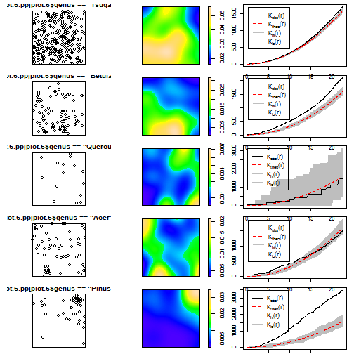

```
##      lty col  key      label
## obs    1   1  obs  K[obs](r)
## theo   2   2 theo K[theo](r)
## hi     1   8   hi   K[hi](r)
## lo     1   8   lo   K[lo](r)
##                                                meaning
## obs            observed value of K(r) for data pattern
## theo                 theoretical value of K(r) for CSR
## hi   upper pointwise envelope of K(r) from simulations
## lo   lower pointwise envelope of K(r) from simulations
```

```r
plot(plot.6.pp[plot.6$genus == "Pinus"])
plot(density(plot.6.pp[plot.6$genus == "Pinus"]))
plot(envelope(plot.6.pp[plot.6$genus == "Pinus"], Kest))
```

```r
plot(plot.7.pp[plot.7$genus == "Tsuga"])
plot(density(plot.7.pp[plot.7$genus == "Tsuga"]))
plot(envelope(plot.7.pp[plot.7$genus == "Tsuga"], Kest))
```

```
## Generating 99 simulations of CSR  ...
## 1, 2, 3, 4, 5, 6, 7, 8, 9, 10, 11, 12, 13, 14, 15,
## 16, 17, 18, 19, 20, 21, 22, 23, 24, 25, 26, 27, 28, 29, 30,
## 31, 32, 33, 34, 35, 36, 37, 38, 39, 40, 41, 42, 43, 44, 45,
## 46, 47, 48, 49, 50, 51, 52, 53, 54, 55, 56, 57, 58, 59, 60,
## 61, 62, 63, 64, 65, 66, 67, 68, 69, 70, 71, 72, 73, 74, 75,
## 76, 77, 78, 79, 80, 81, 82, 83, 84, 85, 86, 87, 88, 89, 90,
## 91, 92, 93, 94, 95, 96, 97, 98,  99.
##
## Done.
```

```
##      lty col  key      label
## obs    1   1  obs  K[obs](r)
## theo   2   2 theo K[theo](r)
## hi     1   8   hi   K[hi](r)
## lo     1   8   lo   K[lo](r)
##                                                meaning
## obs            observed value of K(r) for data pattern
## theo                 theoretical value of K(r) for CSR
## hi   upper pointwise envelope of K(r) from simulations
## lo   lower pointwise envelope of K(r) from simulations
```

```r
plot(plot.7.pp[plot.7$genus == "Betula"])
plot(density(plot.7.pp[plot.7$genus == "Betula"]))
plot(envelope(plot.7.pp[plot.7$genus == "Betula"], Kest))
```

```
## Generating 99 simulations of CSR  ...
## 1, 2, 3, 4, 5, 6, 7, 8, 9, 10, 11, 12, 13, 14, 15,
## 16, 17, 18, 19, 20, 21, 22, 23, 24, 25, 26, 27, 28, 29, 30,
## 31, 32, 33, 34, 35, 36, 37, 38, 39, 40, 41, 42, 43, 44, 45,
## 46, 47, 48, 49, 50, 51, 52, 53, 54, 55, 56, 57, 58, 59, 60,
## 61, 62, 63, 64, 65, 66, 67, 68, 69, 70, 71, 72, 73, 74, 75,
## 76, 77, 78, 79, 80, 81, 82, 83, 84, 85, 86, 87, 88, 89, 90,
## 91, 92, 93, 94, 95, 96, 97, 98,  99.
##
## Done.
```

```
##      lty col  key      label
## obs    1   1  obs  K[obs](r)
## theo   2   2 theo K[theo](r)
## hi     1   8   hi   K[hi](r)
## lo     1   8   lo   K[lo](r)
##                                                meaning
## obs            observed value of K(r) for data pattern
## theo                 theoretical value of K(r) for CSR
## hi   upper pointwise envelope of K(r) from simulations
## lo   lower pointwise envelope of K(r) from simulations
```

```r
plot(plot.7.pp[plot.7$genus == "Quercus"])
plot(density(plot.7.pp[plot.7$genus == "Quercus"]))
plot(envelope(plot.7.pp[plot.7$genus == "Quercus"], Kest))
```

```
## Generating 99 simulations of CSR  ...
## 1, 2, 3, 4, 5, 6, 7, 8, 9, 10, 11, 12, 13, 14, 15,
## 16, 17, 18, 19, 20, 21, 22, 23, 24, 25, 26, 27, 28, 29, 30,
## 31, 32, 33, 34, 35, 36, 37, 38, 39, 40, 41, 42, 43, 44, 45,
## 46, 47, 48, 49, 50, 51, 52, 53, 54, 55, 56, 57, 58, 59, 60,
## 61, 62, 63, 64, 65, 66, 67, 68, 69, 70, 71, 72, 73, 74, 75,
## 76, 77, 78, 79, 80, 81, 82, 83, 84, 85, 86, 87, 88, 89, 90,
## 91, 92, 93, 94, 95, 96, 97, 98,  99.
##
## Done.
```

```
##      lty col  key      label
## obs    1   1  obs  K[obs](r)
## theo   2   2 theo K[theo](r)
## hi     1   8   hi   K[hi](r)
## lo     1   8   lo   K[lo](r)
##                                                meaning
## obs            observed value of K(r) for data pattern
## theo                 theoretical value of K(r) for CSR
## hi   upper pointwise envelope of K(r) from simulations
## lo   lower pointwise envelope of K(r) from simulations
```

```r
plot(plot.7.pp[plot.7$genus == "Acer"])
plot(density(plot.7.pp[plot.7$genus == "Acer"]))
plot(envelope(plot.7.pp[plot.7$genus == "Acer"], Kest))
```

```
## Generating 99 simulations of CSR  ...
## 1, 2, 3, 4, 5, 6, 7, 8, 9, 10, 11, 12, 13, 14, 15,
## 16, 17, 18, 19, 20, 21, 22, 23, 24, 25, 26, 27, 28, 29, 30,
## 31, 32, 33, 34, 35, 36, 37, 38, 39, 40, 41, 42, 43, 44, 45,
## 46, 47, 48, 49, 50, 51, 52, 53, 54, 55, 56, 57, 58, 59, 60,
## 61, 62, 63, 64, 65, 66, 67, 68, 69, 70, 71, 72, 73, 74, 75,
## 76, 77, 78, 79, 80, 81, 82, 83, 84, 85, 86, 87, 88, 89, 90,
## 91, 92, 93, 94, 95, 96, 97, 98,  99.
##
## Done.
```

```
##      lty col  key      label
## obs    1   1  obs  K[obs](r)
## theo   2   2 theo K[theo](r)
## hi     1   8   hi   K[hi](r)
## lo     1   8   lo   K[lo](r)
##                                                meaning
## obs            observed value of K(r) for data pattern
## theo                 theoretical value of K(r) for CSR
## hi   upper pointwise envelope of K(r) from simulations
## lo   lower pointwise envelope of K(r) from simulations
```

```
## Generating 99 simulations of CSR  ...
## 1, 2, 3, 4, 5, 6, 7, 8, 9, 10, 11, 12, 13, 14, 15,
## 16, 17, 18, 19, 20, 21, 22, 23, 24, 25, 26, 27, 28, 29, 30,
## 31, 32, 33, 34, 35, 36, 37, 38, 39, 40, 41, 42, 43, 44, 45,
## 46, 47, 48, 49, 50, 51, 52, 53, 54, 55, 56, 57, 58, 59, 60,
## 61, 62, 63, 64, 65, 66, 67, 68, 69, 70, 71, 72, 73, 74, 75,
## 76, 77, 78, 79, 80, 81, 82, 83, 84, 85, 86, 87, 88, 89, 90,
## 91, 92, 93, 94, 95, 96, 97, 98,  99.
##
## Done.
```

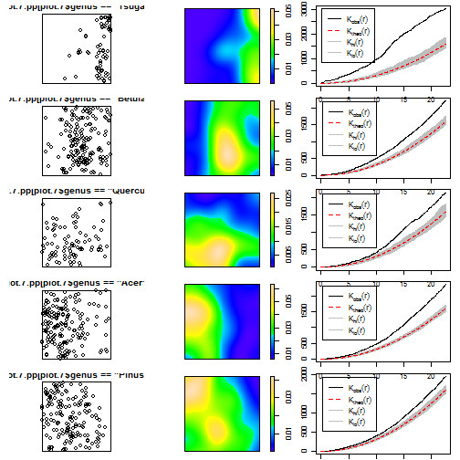

```
##      lty col  key      label
## obs    1   1  obs  K[obs](r)
## theo   2   2 theo K[theo](r)
## hi     1   8   hi   K[hi](r)
## lo     1   8   lo   K[lo](r)
##                                                meaning
## obs            observed value of K(r) for data pattern
## theo                 theoretical value of K(r) for CSR
## hi   upper pointwise envelope of K(r) from simulations
## lo   lower pointwise envelope of K(r) from simulations
```

```r
plot(plot.7.pp[plot.7$genus == "Pinus"])
plot(density(plot.7.pp[plot.7$genus == "Pinus"]))
plot(envelope(plot.7.pp[plot.7$genus == "Pinus"], Kest))
```

```r
plot(plot.8.pp[plot.8$genus == "Tsuga"])
plot(density(plot.8.pp[plot.8$genus == "Tsuga"]))
plot(envelope(plot.8.pp[plot.8$genus == "Tsuga"], Kest))
```

```
## Generating 99 simulations of CSR  ...
## 1, 2, 3, 4, 5, 6, 7, 8, 9, 10, 11, 12, 13, 14, 15,
## 16, 17, 18, 19, 20, 21, 22, 23, 24, 25, 26, 27, 28, 29, 30,
## 31, 32, 33, 34, 35, 36, 37, 38, 39, 40, 41, 42, 43, 44, 45,
## 46, 47, 48, 49, 50, 51, 52, 53, 54, 55, 56, 57, 58, 59, 60,
## 61, 62, 63, 64, 65, 66, 67, 68, 69, 70, 71, 72, 73, 74, 75,
## 76, 77, 78, 79, 80, 81, 82, 83, 84, 85, 86, 87, 88, 89, 90,
## 91, 92, 93, 94, 95, 96, 97, 98,  99.
##
## Done.
```

```
##      lty col  key      label
## obs    1   1  obs  K[obs](r)
## theo   2   2 theo K[theo](r)
## hi     1   8   hi   K[hi](r)
## lo     1   8   lo   K[lo](r)
##                                                meaning
## obs            observed value of K(r) for data pattern
## theo                 theoretical value of K(r) for CSR
## hi   upper pointwise envelope of K(r) from simulations
## lo   lower pointwise envelope of K(r) from simulations
```

```r
plot(plot.8.pp[plot.8$genus == "Betula"])
plot(density(plot.8.pp[plot.8$genus == "Betula"]))
plot(envelope(plot.8.pp[plot.8$genus == "Betula"], Kest))
```

```
## Generating 99 simulations of CSR  ...
## 1, 2, 3, 4, 5, 6, 7, 8, 9, 10, 11, 12, 13, 14, 15,
## 16, 17, 18, 19, 20, 21, 22, 23, 24, 25, 26, 27, 28, 29, 30,
## 31, 32, 33, 34, 35, 36, 37, 38, 39, 40, 41, 42, 43, 44, 45,
## 46, 47, 48, 49, 50, 51, 52, 53, 54, 55, 56, 57, 58, 59, 60,
## 61, 62, 63, 64, 65, 66, 67, 68, 69, 70, 71, 72, 73, 74, 75,
## 76, 77, 78, 79, 80, 81, 82, 83, 84, 85, 86, 87, 88, 89, 90,
## 91, 92, 93, 94, 95, 96, 97, 98,  99.
##
## Done.
```

```
##      lty col  key      label
## obs    1   1  obs  K[obs](r)
## theo   2   2 theo K[theo](r)
## hi     1   8   hi   K[hi](r)
## lo     1   8   lo   K[lo](r)
##                                                meaning
## obs            observed value of K(r) for data pattern
## theo                 theoretical value of K(r) for CSR
## hi   upper pointwise envelope of K(r) from simulations
## lo   lower pointwise envelope of K(r) from simulations
```

```r
plot(plot.8.pp[plot.8$genus == "Quercus"])
plot(density(plot.8.pp[plot.8$genus == "Quercus"]))
plot(envelope(plot.8.pp[plot.8$genus == "Quercus"], Kest))
```

```
## Generating 99 simulations of CSR  ...
## 1, 2, 3, 4, 5, 6, 7, 8, 9, 10, 11, 12, 13, 14, 15,
## 16, 17, 18, 19, 20, 21, 22, 23, 24, 25, 26, 27, 28, 29, 30,
## 31, 32, 33, 34, 35, 36, 37, 38, 39, 40, 41, 42, 43, 44, 45,
## 46, 47, 48, 49, 50, 51, 52, 53, 54, 55, 56, 57, 58, 59, 60,
## 61, 62, 63, 64, 65, 66, 67, 68, 69, 70, 71, 72, 73, 74, 75,
## 76, 77, 78, 79, 80, 81, 82, 83, 84, 85, 86, 87, 88, 89, 90,
## 91, 92, 93, 94, 95, 96, 97, 98,  99.
##
## Done.
```

```
##      lty col  key      label
## obs    1   1  obs  K[obs](r)
## theo   2   2 theo K[theo](r)
## hi     1   8   hi   K[hi](r)
## lo     1   8   lo   K[lo](r)
##                                                meaning
## obs            observed value of K(r) for data pattern
## theo                 theoretical value of K(r) for CSR
## hi   upper pointwise envelope of K(r) from simulations
## lo   lower pointwise envelope of K(r) from simulations
```

```r
plot(plot.8.pp[plot.8$genus == "Acer"])
plot(density(plot.8.pp[plot.8$genus == "Acer"]))
plot(envelope(plot.8.pp[plot.8$genus == "Acer"], Kest))
```

```
## Generating 99 simulations of CSR  ...
## 1, 2, 3, 4, 5, 6, 7, 8, 9, 10, 11, 12, 13, 14, 15,
## 16, 17, 18, 19, 20, 21, 22, 23, 24, 25, 26, 27, 28, 29, 30,
## 31, 32, 33, 34, 35, 36, 37, 38, 39, 40, 41, 42, 43, 44, 45,
## 46, 47, 48, 49, 50, 51, 52, 53, 54, 55, 56, 57, 58, 59, 60,
## 61, 62, 63, 64, 65, 66, 67, 68, 69, 70, 71, 72, 73, 74, 75,
## 76, 77, 78, 79, 80, 81, 82, 83, 84, 85, 86, 87, 88, 89, 90,
## 91, 92, 93, 94, 95, 96, 97, 98,  99.
##
## Done.
```

```
##      lty col  key      label
## obs    1   1  obs  K[obs](r)
## theo   2   2 theo K[theo](r)
## hi     1   8   hi   K[hi](r)
## lo     1   8   lo   K[lo](r)
##                                                meaning
## obs            observed value of K(r) for data pattern
## theo                 theoretical value of K(r) for CSR
## hi   upper pointwise envelope of K(r) from simulations
## lo   lower pointwise envelope of K(r) from simulations
```

```
## Generating 99 simulations of CSR  ...
## 1, 2, 3, 4, 5, 6, 7, 8, 9, 10, 11, 12, 13, 14, 15,
## 16, 17, 18, 19, 20, 21, 22, 23, 24, 25, 26, 27, 28, 29, 30,
## 31, 32, 33, 34, 35, 36, 37, 38, 39, 40, 41, 42, 43, 44, 45,
## 46, 47, 48, 49, 50, 51, 52, 53, 54, 55, 56, 57, 58, 59, 60,
## 61, 62, 63, 64, 65, 66, 67, 68, 69, 70, 71, 72, 73, 74, 75,
## 76, 77, 78, 79, 80, 81, 82, 83, 84, 85, 86, 87, 88, 89, 90,
## 91, 92, 93, 94, 95, 96, 97, 98,  99.
##
## Done.
```

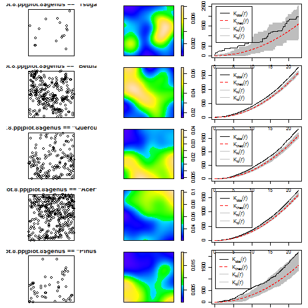

```
##      lty col  key      label
## obs    1   1  obs  K[obs](r)
## theo   2   2 theo K[theo](r)
## hi     1   8   hi   K[hi](r)
## lo     1   8   lo   K[lo](r)
##                                                meaning
## obs            observed value of K(r) for data pattern
## theo                 theoretical value of K(r) for CSR
## hi   upper pointwise envelope of K(r) from simulations
## lo   lower pointwise envelope of K(r) from simulations
```

```r
plot(plot.8.pp[plot.8$genus == "Pinus"])
plot(density(plot.8.pp[plot.8$genus == "Pinus"]))
plot(envelope(plot.8.pp[plot.8$genus == "Pinus"], Kest))
```

Next, run maximum absolute deviation tests of CSR on ppp data

```r
mad.test(plot.1.pp[plot.1$genus == "Tsuga"], Lest, verbose = FALSE, nsim = 99)
```

```
##
##  Maximum absolute deviation test of CSR
##  Monte Carlo test based on 99 simulations
##  Summary function: L(r)
##  Reference function: sample mean
##  Interval of distance values: [0, 22.5]
##
## data:  plot.1.pp[plot.1$genus == "Tsuga"]
## mad = 1.016, rank = 1, p-value = 0.01
```

```r
mad.test(plot.1.pp[plot.1$genus == "Betula"], Lest, verbose = FALSE, nsim = 99)
```

```
##
##  Maximum absolute deviation test of CSR
##  Monte Carlo test based on 99 simulations
##  Summary function: L(r)
##  Reference function: sample mean
##  Interval of distance values: [0, 22.5]
##
## data:  plot.1.pp[plot.1$genus == "Betula"]
## mad = 17, rank = 1, p-value = 0.01
```

```r
mad.test(plot.1.pp[plot.1$genus == "Quercus"], Lest, verbose = FALSE, nsim = 99)
```

```
##
##  Maximum absolute deviation test of CSR
##  Monte Carlo test based on 99 simulations
##  Summary function: L(r)
##  Reference function: sample mean
##  Interval of distance values: [0, 22.5]
##
## data:  plot.1.pp[plot.1$genus == "Quercus"]
## mad = 5.256, rank = 1, p-value = 0.01
```

```r
mad.test(plot.1.pp[plot.1$genus == "Acer"], Lest, verbose = FALSE, nsim = 99)
```

```
##
##  Maximum absolute deviation test of CSR
##  Monte Carlo test based on 99 simulations
##  Summary function: L(r)
##  Reference function: sample mean
##  Interval of distance values: [0, 22.5]
##
## data:  plot.1.pp[plot.1$genus == "Acer"]
## mad = 6.744, rank = 1, p-value = 0.01
```

```r
mad.test(plot.1.pp[plot.1$genus == "Pinus"], Lest, verbose = FALSE, nsim = 99)
```

```
##
##  Maximum absolute deviation test of CSR
##  Monte Carlo test based on 99 simulations
##  Summary function: L(r)
##  Reference function: sample mean
##  Interval of distance values: [0, 22.5]
##
## data:  plot.1.pp[plot.1$genus == "Pinus"]
## mad = 1.467, rank = 24, p-value = 0.24
```

```r
mad.test(plot.2.pp[plot.2$genus == "Tsuga"], Lest, verbose = FALSE, nsim = 99)
```

```
##
##  Maximum absolute deviation test of CSR
##  Monte Carlo test based on 99 simulations
##  Summary function: L(r)
##  Reference function: sample mean
##  Interval of distance values: [0, 22.5]
##
## data:  plot.2.pp[plot.2$genus == "Tsuga"]
## mad = 1.196, rank = 1, p-value = 0.01
```

```r
mad.test(plot.2.pp[plot.2$genus == "Betula"], Lest, verbose = FALSE, nsim = 99)
```

```
##
##  Maximum absolute deviation test of CSR
##  Monte Carlo test based on 99 simulations
##  Summary function: L(r)
##  Reference function: sample mean
##  Interval of distance values: [0, 22.5]
##
## data:  plot.2.pp[plot.2$genus == "Betula"]
## mad = 3.826, rank = 10, p-value = 0.1
```

```r
mad.test(plot.2.pp[plot.2$genus == "Quercus"], Lest, verbose = FALSE, nsim = 99)
```

```
##
##  Maximum absolute deviation test of CSR
##  Monte Carlo test based on 99 simulations
##  Summary function: L(r)
##  Reference function: sample mean
##  Interval of distance values: [0, 22.5]
##
## data:  plot.2.pp[plot.2$genus == "Quercus"]
## mad = 2.451, rank = 1, p-value = 0.01
```

```r
mad.test(plot.2.pp[plot.2$genus == "Acer"], Lest, verbose = FALSE, nsim = 99)
```

```
##
##  Maximum absolute deviation test of CSR
##  Monte Carlo test based on 99 simulations
##  Summary function: L(r)
##  Reference function: sample mean
##  Interval of distance values: [0, 22.5]
##
## data:  plot.2.pp[plot.2$genus == "Acer"]
## mad = 1.653, rank = 5, p-value = 0.05
```

```r
mad.test(plot.2.pp[plot.2$genus == "Pinus"], Lest, verbose = FALSE, nsim = 99)
```

```
##
##  Maximum absolute deviation test of CSR
##  Monte Carlo test based on 99 simulations
##  Summary function: L(r)
##  Reference function: sample mean
##  Interval of distance values: [0, 22.5]
##
## data:  plot.2.pp[plot.2$genus == "Pinus"]
## mad = 3.442, rank = 1, p-value = 0.01
```

```r
mad.test(plot.3.pp[plot.3$genus == "Tsuga"], Lest, verbose = FALSE, nsim = 99)
```

```
##
##  Maximum absolute deviation test of CSR
##  Monte Carlo test based on 99 simulations
##  Summary function: L(r)
##  Reference function: sample mean
##  Interval of distance values: [0, 22.5]
##
## data:  plot.3.pp[plot.3$genus == "Tsuga"]
## mad = 1.032, rank = 1, p-value = 0.01
```

```r
mad.test(plot.3.pp[plot.3$genus == "Betula"], Lest, verbose = FALSE, nsim = 99)
```

```
##
##  Maximum absolute deviation test of CSR
##  Monte Carlo test based on 99 simulations
##  Summary function: L(r)
##  Reference function: sample mean
##  Interval of distance values: [0, 22.5]
##
## data:  plot.3.pp[plot.3$genus == "Betula"]
## mad = 3.301, rank = 1, p-value = 0.01
```

```r
mad.test(plot.3.pp[plot.3$genus == "Quercus"], Lest, verbose = FALSE, nsim = 99)
```

```
##
##  Maximum absolute deviation test of CSR
##  Monte Carlo test based on 99 simulations
##  Summary function: L(r)
##  Reference function: sample mean
##  Interval of distance values: [0, 22.5]
##
## data:  plot.3.pp[plot.3$genus == "Quercus"]
## mad = 3.272, rank = 1, p-value = 0.01
```

```r
mad.test(plot.3.pp[plot.3$genus == "Acer"], Lest, verbose = FALSE, nsim = 99)
```

```
##
##  Maximum absolute deviation test of CSR
##  Monte Carlo test based on 99 simulations
##  Summary function: L(r)
##  Reference function: sample mean
##  Interval of distance values: [0, 22.5]
##
## data:  plot.3.pp[plot.3$genus == "Acer"]
## mad = 3.35, rank = 2, p-value = 0.02
```

```r
mad.test(plot.3.pp[plot.3$genus == "Pinus"], Lest, verbose = FALSE, nsim = 99)
```

```
##
##  Maximum absolute deviation test of CSR
##  Monte Carlo test based on 99 simulations
##  Summary function: L(r)
##  Reference function: sample mean
##  Interval of distance values: [0, 22.5]
##
## data:  plot.3.pp[plot.3$genus == "Pinus"]
## mad = 7.287, rank = 3, p-value = 0.03
```

```r
mad.test(plot.4.pp[plot.4$genus == "Tsuga"], Lest, verbose = FALSE, nsim = 99)
```

```
##
##  Maximum absolute deviation test of CSR
##  Monte Carlo test based on 99 simulations
##  Summary function: L(r)
##  Reference function: sample mean
##  Interval of distance values: [0, 22.5]
##
## data:  plot.4.pp[plot.4$genus == "Tsuga"]
## mad = 0.6014, rank = 1, p-value = 0.01
```

```r
mad.test(plot.4.pp[plot.4$genus == "Betula"], Lest, verbose = FALSE, nsim = 99)
```

```
##
##  Maximum absolute deviation test of CSR
##  Monte Carlo test based on 99 simulations
##  Summary function: L(r)
##  Reference function: sample mean
##  Interval of distance values: [0, 22.5]
##
## data:  plot.4.pp[plot.4$genus == "Betula"]
## mad = 2.95, rank = 1, p-value = 0.01
```

```r
mad.test(plot.4.pp[plot.4$genus == "Quercus"], Lest, verbose = FALSE, nsim = 99)
```

```
##
##  Maximum absolute deviation test of CSR
##  Monte Carlo test based on 99 simulations
##  Summary function: L(r)
##  Reference function: sample mean
##  Interval of distance values: [0, 22.5]
##
## data:  plot.4.pp[plot.4$genus == "Quercus"]
## mad = 2.418, rank = 4, p-value = 0.04
```

```r
mad.test(plot.4.pp[plot.4$genus == "Acer"], Lest, verbose = FALSE, nsim = 99)
```

```
##
##  Maximum absolute deviation test of CSR
##  Monte Carlo test based on 99 simulations
##  Summary function: L(r)
##  Reference function: sample mean
##  Interval of distance values: [0, 22.5]
##
## data:  plot.4.pp[plot.4$genus == "Acer"]
## mad = 3.07, rank = 1, p-value = 0.01
```

```r
mad.test(plot.4.pp[plot.4$genus == "Pinus"], Lest, verbose = FALSE, nsim = 99)
```

```
##
##  Maximum absolute deviation test of CSR
##  Monte Carlo test based on 99 simulations
##  Summary function: L(r)
##  Reference function: sample mean
##  Interval of distance values: [0, 22.5]
##
## data:  plot.4.pp[plot.4$genus == "Pinus"]
## mad = 10.7, rank = 17, p-value = 0.17
```

```r
mad.test(plot.5.pp[plot.5$genus == "Tsuga"], Lest, verbose = FALSE, nsim = 99)
```

```
##
##  Maximum absolute deviation test of CSR
##  Monte Carlo test based on 99 simulations
##  Summary function: L(r)
##  Reference function: sample mean
##  Interval of distance values: [0, 22.5]
##
## data:  plot.5.pp[plot.5$genus == "Tsuga"]
## mad = 0.7566, rank = 1, p-value = 0.01
```

```r
mad.test(plot.5.pp[plot.5$genus == "Betula"], Lest, verbose = FALSE, nsim = 99)
```

```
##
##  Maximum absolute deviation test of CSR
##  Monte Carlo test based on 99 simulations
##  Summary function: L(r)
##  Reference function: sample mean
##  Interval of distance values: [0, 22.5]
##
## data:  plot.5.pp[plot.5$genus == "Betula"]
## mad = 2.039, rank = 1, p-value = 0.01
```

```r
mad.test(plot.5.pp[plot.5$genus == "Quercus"], Lest, verbose = FALSE, nsim = 99)
```

```
##
##  Maximum absolute deviation test of CSR
##  Monte Carlo test based on 99 simulations
##  Summary function: L(r)
##  Reference function: sample mean
##  Interval of distance values: [0, 22.5]
##
## data:  plot.5.pp[plot.5$genus == "Quercus"]
## mad = 2.853, rank = 12, p-value = 0.12
```

```r
mad.test(plot.5.pp[plot.5$genus == "Acer"], Lest, verbose = FALSE, nsim = 99)
```

```
##
##  Maximum absolute deviation test of CSR
##  Monte Carlo test based on 99 simulations
##  Summary function: L(r)
##  Reference function: sample mean
##  Interval of distance values: [0, 22.5]
##
## data:  plot.5.pp[plot.5$genus == "Acer"]
## mad = 1.97, rank = 3, p-value = 0.03
```

```r
mad.test(plot.5.pp[plot.5$genus == "Pinus"], Lest, verbose = FALSE, nsim = 99)
```

```
## Error: Some function values were infinite or NaN at distances r up to
## 22.5. Please specify a shorter 'rinterval'
```

```r
mad.test(plot.6.pp[plot.6$genus == "Tsuga"], Lest, verbose = FALSE, nsim = 99)
```

```
##
##  Maximum absolute deviation test of CSR
##  Monte Carlo test based on 99 simulations
##  Summary function: L(r)
##  Reference function: sample mean
##  Interval of distance values: [0, 22.5]
##
## data:  plot.6.pp[plot.6$genus == "Tsuga"]
## mad = 1.098, rank = 1, p-value = 0.01
```

```r
mad.test(plot.6.pp[plot.6$genus == "Betula"], Lest, verbose = FALSE, nsim = 99)
```

```
##
##  Maximum absolute deviation test of CSR
##  Monte Carlo test based on 99 simulations
##  Summary function: L(r)
##  Reference function: sample mean
##  Interval of distance values: [0, 22.5]
##
## data:  plot.6.pp[plot.6$genus == "Betula"]
## mad = 3.468, rank = 1, p-value = 0.01
```

```r
mad.test(plot.6.pp[plot.6$genus == "Quercus"], Lest, verbose = FALSE, nsim = 99)
```

```
##
##  Maximum absolute deviation test of CSR
##  Monte Carlo test based on 99 simulations
##  Summary function: L(r)
##  Reference function: sample mean
##  Interval of distance values: [0, 22.5]
##
## data:  plot.6.pp[plot.6$genus == "Quercus"]
## mad = 4.589, rank = 59, p-value = 0.59
```

```r
mad.test(plot.6.pp[plot.6$genus == "Acer"], Lest, verbose = FALSE, nsim = 99)
```

```
##
##  Maximum absolute deviation test of CSR
##  Monte Carlo test based on 99 simulations
##  Summary function: L(r)
##  Reference function: sample mean
##  Interval of distance values: [0, 22.5]
##
## data:  plot.6.pp[plot.6$genus == "Acer"]
## mad = 3.882, rank = 1, p-value = 0.01
```

```r
mad.test(plot.6.pp[plot.6$genus == "Pinus"], Lest, verbose = FALSE, nsim = 99)
```

```
##
##  Maximum absolute deviation test of CSR
##  Monte Carlo test based on 99 simulations
##  Summary function: L(r)
##  Reference function: sample mean
##  Interval of distance values: [0, 22.5]
##
## data:  plot.6.pp[plot.6$genus == "Pinus"]
## mad = 11.43, rank = 1, p-value = 0.01
```

```r
mad.test(plot.7.pp[plot.7$genus == "Tsuga"], Lest, verbose = FALSE, nsim = 99)
```

```
##
##  Maximum absolute deviation test of CSR
##  Monte Carlo test based on 99 simulations
##  Summary function: L(r)
##  Reference function: sample mean
##  Interval of distance values: [0, 22.5]
##
## data:  plot.7.pp[plot.7$genus == "Tsuga"]
## mad = 10.23, rank = 1, p-value = 0.01
```

```r
mad.test(plot.7.pp[plot.7$genus == "Betula"], Lest, verbose = FALSE, nsim = 99)
```

```
##
##  Maximum absolute deviation test of CSR
##  Monte Carlo test based on 99 simulations
##  Summary function: L(r)
##  Reference function: sample mean
##  Interval of distance values: [0, 22.5]
##
## data:  plot.7.pp[plot.7$genus == "Betula"]
## mad = 4.043, rank = 1, p-value = 0.01
```

```r
mad.test(plot.7.pp[plot.7$genus == "Quercus"], Lest, verbose = FALSE, nsim = 99)
```

```
##
##  Maximum absolute deviation test of CSR
##  Monte Carlo test based on 99 simulations
##  Summary function: L(r)
##  Reference function: sample mean
##  Interval of distance values: [0, 22.5]
##
## data:  plot.7.pp[plot.7$genus == "Quercus"]
## mad = 3.823, rank = 1, p-value = 0.01
```

```r
mad.test(plot.7.pp[plot.7$genus == "Acer"], Lest, verbose = FALSE, nsim = 99)
```

```
##
##  Maximum absolute deviation test of CSR
##  Monte Carlo test based on 99 simulations
##  Summary function: L(r)
##  Reference function: sample mean
##  Interval of distance values: [0, 22.5]
##
## data:  plot.7.pp[plot.7$genus == "Acer"]
## mad = 4.794, rank = 1, p-value = 0.01
```

```r
mad.test(plot.7.pp[plot.7$genus == "Pinus"], Lest, verbose = FALSE, nsim = 99)
```

```
##
##  Maximum absolute deviation test of CSR
##  Monte Carlo test based on 99 simulations
##  Summary function: L(r)
##  Reference function: sample mean
##  Interval of distance values: [0, 22.5]
##
## data:  plot.7.pp[plot.7$genus == "Pinus"]
## mad = 2.411, rank = 1, p-value = 0.01
```

```r
mad.test(plot.8.pp[plot.8$genus == "Tsuga"], Lest, verbose = FALSE, nsim = 99)
```

```
##
##  Maximum absolute deviation test of CSR
##  Monte Carlo test based on 99 simulations
##  Summary function: L(r)
##  Reference function: sample mean
##  Interval of distance values: [0, 22.5]
##
## data:  plot.8.pp[plot.8$genus == "Tsuga"]
## mad = 8.653, rank = 5, p-value = 0.05
```

```r
mad.test(plot.8.pp[plot.8$genus == "Betula"], Lest, verbose = FALSE, nsim = 99)
```

```
##
##  Maximum absolute deviation test of CSR
##  Monte Carlo test based on 99 simulations
##  Summary function: L(r)
##  Reference function: sample mean
##  Interval of distance values: [0, 22.5]
##
## data:  plot.8.pp[plot.8$genus == "Betula"]
## mad = 1.542, rank = 1, p-value = 0.01
```

```r
mad.test(plot.8.pp[plot.8$genus == "Quercus"], Lest, verbose = FALSE, nsim = 99)
```

```
##
##  Maximum absolute deviation test of CSR
##  Monte Carlo test based on 99 simulations
##  Summary function: L(r)
##  Reference function: sample mean
##  Interval of distance values: [0, 22.5]
##
## data:  plot.8.pp[plot.8$genus == "Quercus"]
## mad = 1.787, rank = 1, p-value = 0.01
```

```r
mad.test(plot.8.pp[plot.8$genus == "Acer"], Lest, verbose = FALSE, nsim = 99)
```

```
##
##  Maximum absolute deviation test of CSR
##  Monte Carlo test based on 99 simulations
##  Summary function: L(r)
##  Reference function: sample mean
##  Interval of distance values: [0, 22.5]
##
## data:  plot.8.pp[plot.8$genus == "Acer"]
## mad = 1.194, rank = 1, p-value = 0.01
```

```r
mad.test(plot.8.pp[plot.8$genus == "Pinus"], Lest, verbose = FALSE, nsim = 99)
```

```
##
##  Maximum absolute deviation test of CSR
##  Monte Carlo test based on 99 simulations
##  Summary function: L(r)
##  Reference function: sample mean
##  Interval of distance values: [0, 22.5]
##
## data:  plot.8.pp[plot.8$genus == "Pinus"]
## mad = 4.07, rank = 1, p-value = 0.01
```

Plot age x dbh, with smoother and marginal histograms - ms. Figure 8

```r
#### Extract tree ages, combine with species and dbh from trees

attach(dendro)

tree.sprout <- by(dendro[, 6], INDICES = as.factor(dendro$TreeNum), min, simplify = FALSE)

tree.ids <- by(dendro[, 1], INDICES = as.factor(dendro$TreeNum), mean, simplify = FALSE)

sprout <- NULL
for (i in 1:length(tree.sprout)) sprout[i] <- tree.sprout[[i]]

plotnum <- NULL
for (i in 1:length(tree.ids)) plotnum[i] <- tree.ids[[i]]

tree.ids <- as.integer(names(tree.sprout))

tree.ages <- cbind(tree.ids, sprout)

tree.age <- 2003 - tree.ages[, 2]

tree.ages <- cbind(tree.ages, tree.age)

tree.ages <- as.data.frame(tree.ages)

tree.ages[, 4] <- plotnum

names(tree.ages)[4] <- "plot"


## deal with crashes from duplicate records at 27, 119, 230

for (i in 1:26) {
    tree.ages[i, 5] <- trees$species[trees$tree == tree.ages$tree.ids[i]]
}
for (i in 28:117) {
    tree.ages[i, 5] <- trees$species[trees$tree == tree.ages$tree.ids[i]]
}
for (i in 119:229) {
    tree.ages[i, 5] <- trees$species[trees$tree == tree.ages$tree.ids[i]]
}

tree.ages[27, 5] <- "TSCA"
tree.ages[118, 5] <- "PIST"
tree.ages[230, 5] <- "TSCA"

for (i in 1:26) {
    tree.ages[i, 6] <- trees$dbh[trees$tree == tree.ages$tree.ids[i]]
}
for (i in 28:117) {
    tree.ages[i, 6] <- trees$dbh[trees$tree == tree.ages$tree.ids[i]]
}
for (i in 119:229) {
    tree.ages[i, 6] <- trees$dbh[trees$tree == tree.ages$tree.ids[i]]
}

tree.ages[27, 6] <- 15
tree.ages[118, 6] <- 62.5
tree.ages[230, 6] <- 39.5

for (i in 1:26) {
    tree.ages[i, 7] <- trees$genus[trees$tree == tree.ages$tree.ids[i]]
}
for (i in 28:117) {
    tree.ages[i, 7] <- trees$genus[trees$tree == tree.ages$tree.ids[i]]
}
for (i in 119:229) {
    tree.ages[i, 7] <- trees$genus[trees$tree == tree.ages$tree.ids[i]]
}

tree.ages[27, 7] <- "Tsuga"
tree.ages[118, 7] <- "Pinus"
tree.ages[230, 7] <- "Tsuga"

tree.ages[, 8] <- NA

tree.ages[, 8] <- ifelse(tree.ages$plot < 7, tree.ages[, 8] <- "hemlock", tree.ages[,
    8] <- "hardwood")

tree.ages[, 9] <- NA
tree.ages[, 9] <- ifelse(tree.ages$plot > 3 & tree.ages$plot < 8, tree.ages[,
    9] <- "Ridge", tree.ages[, 9] <- "Valley")

detach(dendro)

names(tree.ages)[5:9] <- c("species", "dbh", "genus", "init.treat", "block")


head(tree.ages)
```

```
##   tree.ids sprout tree.age plot species  dbh  genus init.treat block
## 1        3   1961       42    4    TSCA  5.9  Tsuga    hemlock Ridge
## 2        5   1917       86    4    BELE 11.9 Betula    hemlock Ridge
## 3        9   1953       50    4    TSCA  8.3  Tsuga    hemlock Ridge
## 4       11   1927       76    4    ACRU 16.2   Acer    hemlock Ridge
## 5       21   1946       57    4    TSCA  6.4  Tsuga    hemlock Ridge
## 6       28   1937       66    4    TSCA 18.0  Tsuga    hemlock Ridge
```

Create the plot

```r
#original colors for all genera

genera.colors <- c("firebrick4", "coral", "orange4", "black", "orange",
        "darkmagenta", "darkolivegreen1", "yellow", "orange3", "olivedrab3",
            "red", "tan4", "maroon4", "darkgreen")

age.cols <- genera.colors[c(1,2, 7,9, 10, 12, 14)]

for (i in 1:length(genera)) tree.ages[tree.ages$genus == genera[i],10] <- genera.colors[i]
names(tree.ages)[10] <- "tree.color"

tree.ages <- drop.levels(tree.ages)
tree.ages$init.treat <- as.factor(tree.ages$init.treat)
tree.ages$tree.color <- as.factor(tree.ages$tree.color)
tree.ages$block <- as.factor(tree.ages$block)


vh <- tree.ages[tree.ages$block=="Valley" & tree.ages$init.treat=="hemlock",]
vd <- tree.ages[tree.ages$block=="Valley" & tree.ages$init.treat=="hardwood",]
rh <- tree.ages[tree.ages$block=="Ridge" & tree.ages$init.treat=="hemlock",]
rd <- tree.ages[tree.ages$block=="Ridge" & tree.ages$init.treat=="hardwood",]


#histograms
#age distributions
hist.vh.age <- hist(vh$tree.age[vh$genus=="Tsuga"], plot=FALSE, breaks=seq(10,150,10))
hist.vh.bet.age<- hist(vh$tree.age[vh$genus=="Betula"], plot=FALSE, breaks=seq(10,150,10))
hist.vh.acer.age<- hist(vh$tree.age[vh$genus=="Acer"], plot=FALSE, breaks=seq(10,150,10))
hist.vh.quercus.age<- hist(vh$tree.age[vh$genus=="Quercus"], plot=FALSE, breaks=seq(10,150,10))
hist.vh.pinus.age<- hist(vh$tree.age[vh$genus=="Pinus"], plot=FALSE, breaks=seq(10,150,10))

hist.rh.age <- hist(rh$tree.age[rh$genus=="Tsuga"], plot=FALSE, breaks=seq(10,150,10))
hist.rh.bet.age<- hist(rh$tree.age[rh$genus=="Betula"], plot=FALSE, breaks=seq(10,150,10))
hist.rh.acer.age<- hist(rh$tree.age[rh$genus=="Acer"], plot=FALSE, breaks=seq(10,150,10))
hist.rh.quercus.age<- hist(rh$tree.age[rh$genus=="Quercus"], plot=FALSE, breaks=seq(10,150,10))
hist.rh.pinus.age<- hist(rh$tree.age[rh$genus=="Pinus"], plot=FALSE, breaks=seq(10,150,10))

hist.vd.age <- hist(vd$tree.age[vd$genus=="Tsuga"], plot=FALSE, breaks=seq(10,150,10))
hist.vd.bet.age<- hist(vd$tree.age[vd$genus=="Betula"], plot=FALSE, breaks=seq(10,150,10))
hist.vd.acer.age<- hist(vd$tree.age[vd$genus=="Acer"], plot=FALSE, breaks=seq(10,150,10))
hist.vd.quercus.age<- hist(vd$tree.age[vd$genus=="Quercus"], plot=FALSE, breaks=seq(10,150,10))
hist.vd.pinus.age<- hist(vd$tree.age[vd$genus=="Pinus"], plot=FALSE, breaks=seq(10,150,10))

hist.rd.age <- hist(rd$tree.age[rd$genus=="Tsuga"], plot=FALSE, breaks=seq(10,150,10))
hist.rd.bet.age <- hist(rd$tree.age[rd$genus=="Betula"], plot=FALSE, breaks=seq(10,150,10))
hist.rd.acer.age <- hist(rd$tree.age[rd$genus=="Acer"], plot=FALSE, breaks=seq(10,150,10))
hist.rd.quercus.age<- hist(rd$tree.age[rd$genus=="Quercus"], plot=FALSE, breaks=seq(10,150,10))
hist.rd.pinus.age<- hist(rd$tree.age[rd$genus=="Pinus"], plot=FALSE, breaks=seq(10,150,10))

#dbh distributions

hist.vh.dbh <- hist(vh$dbh[vh$genus=="Tsuga"], plot=FALSE, breaks=seq(0,80,10))
hist.vh.bet.dbh <- hist(vh$dbh[vh$genus=="Betula"], plot=FALSE, breaks=seq(0,80,10))
hist.vh.acer.dbh <- hist(vh$dbh[vh$genus=="Acer"], plot=FALSE, breaks=seq(0,80,10))
hist.vh.quercus.dbh <- hist(vh$dbh[vh$genus=="Quercus"], plot=FALSE, breaks=seq(0,80,10))
hist.vh.pinus.dbh <- hist(vh$dbh[vh$genus=="Pinus"], plot=FALSE, breaks=seq(0,80,10))

hist.rh.dbh <- hist(rh$dbh[rh$genus=="Tsuga"], plot=FALSE, breaks=seq(0,80,10))
hist.rh.bet.dbh <- hist(rh$dbh[rh$genus=="Betula"], plot=FALSE, breaks=seq(0,80,10))
hist.rh.acer.dbh <- hist(rh$dbh[rh$genus=="Acer"], plot=FALSE, breaks=seq(0,80,10))
hist.rh.quercus.dbh <- hist(rh$dbh[rh$genus=="Quercus"], plot=FALSE, breaks=seq(0,80,10))
hist.rh.pinus.dbh <- hist(rh$dbh[rh$genus=="Pinus"], plot=FALSE, breaks=seq(0,80,10))


hist.vd.dbh <- hist(vd$dbh[vd$genus=="Tsuga"], plot=FALSE, breaks=seq(0,80,10))
hist.vd.bet.dbh <- hist(vd$dbh[vd$genus=="Betula"], plot=FALSE, breaks=seq(0,80,10))
hist.vd.acer.dbh <- hist(vd$dbh[vd$genus=="Acer"], plot=FALSE, breaks=seq(0,80,10))
hist.vd.quercus.dbh <- hist(vd$dbh[vd$genus=="Quercus"], plot=FALSE, breaks=seq(0,80,10))
hist.vd.pinus.dbh <- hist(vd$dbh[vd$genus=="Pinus"], plot=FALSE, breaks=seq(0,80,10))

hist.rd.dbh <- hist(rd$dbh[rd$genus=="Tsuga"], plot=FALSE, breaks=seq(0,80,10))
hist.rd.bet.dbh <- hist(rd$dbh[rd$genus=="Betula"], plot=FALSE, breaks=seq(0,80,10))
hist.rd.acer.dbh <- hist(rd$dbh[rd$genus=="Acer"], plot=FALSE, breaks=seq(0,80,10))
hist.rd.quercus.dbh <- hist(rd$dbh[rd$genus=="Quercus"], plot=FALSE, breaks=seq(0,80,10))
hist.rd.pinus.dbh <- hist(rd$dbh[rd$genus=="Pinus"], plot=FALSE, breaks=seq(0,80,10))


vh.ages <- rbind(hist.vh.age$counts, hist.vh.bet.age$counts, hist.vh.quercus.age$counts,
        hist.vh.acer.age$counts, hist.vh.pinus.age$counts)
rh.ages <- rbind(hist.rh.age$counts, hist.rh.bet.age$counts, hist.rh.quercus.age$counts,
            hist.rh.acer.age$counts, hist.rh.pinus.age$counts)
vd.ages <- rbind(hist.vd.age$counts, hist.vd.bet.age$counts, hist.vd.quercus.age$counts,
            hist.vd.acer.age$counts, hist.vd.pinus.age$counts)
rd.ages <- rbind(hist.rd.age$counts, hist.rd.bet.age$counts, hist.rd.quercus.age$counts,
            hist.rd.acer.age$counts, hist.rd.pinus.age$counts)


vh.dbh <- rbind(hist.vh.dbh$counts, hist.vh.bet.dbh$counts, hist.vh.quercus.dbh$counts,
            hist.vh.acer.dbh$counts, hist.vh.pinus.dbh$counts)
rh.dbh <- rbind(hist.rh.dbh$counts, hist.rh.bet.dbh$counts, hist.rh.quercus.dbh$counts,
            hist.rh.acer.dbh$counts, hist.rh.pinus.dbh$counts)
vd.dbh <- rbind(hist.vd.dbh$counts, hist.vd.bet.dbh$counts, hist.vd.quercus.dbh$counts,
            hist.vd.acer.dbh$counts, hist.vd.pinus.dbh$counts)
rd.dbh <- rbind(hist.rd.dbh$counts, hist.rd.bet.dbh$counts, hist.rd.quercus.dbh$counts,
            hist.rd.acer.dbh$counts, hist.rd.pinus.dbh$counts)


#some plotting setup

five.colors <-c("darkgreen","coral", "tan4", "firebrick4", "olivedrab3")
limits <- list(xlims=c(10,150), ylims=c(0,80))
xpreds <- seq(10,150,1)
xpreds.rev <- sort(xpreds, decreasing=TRUE)

maxcount.ages <- max(c(colSums(vh.ages), colSums(rh.ages), colSums(vd.ages), colSums(rd.ages) ) )
maxcount.dbh <- max(c(colSums(vh.dbh), colSums(rh.dbh), colSums(vd.dbh), colSums(rd.dbh) ) )
```

```r
#pdf(file="Figure 7 - age_dbh.pdf", width=6, height=6.5, colormodel="cmyk")

layout(matrix(c(0, 1, 2, 0, 3, 9, 10, 5, 4, 11, 12, 6, 0, 7, 8, 0), nrow=4, byrow=TRUE), heights=c(lcm(1.5), lcm(5.08), lcm(5.08), lcm(1.5)), widths=c(lcm(1.5), lcm(5.08), lcm(5.08), lcm(1.5)) )

#layout.show(12)


#barcharts

par(mar=c(0,1,0,1))
barplot(vh.ages, axes=FALSE, ylim=c(0,maxcount.ages), space=0, col=five.colors)
barplot(rh.ages, axes=FALSE, ylim=c(0,maxcount.ages), space=0, col=five.colors)
par(mar=c(1,0,.5,0))
barplot(vh.dbh, axes=FALSE, xlim=c(maxcount.dbh,0),  space=0, horiz=TRUE, col=five.colors)

mtext("DBH (cm)", side=2, line=.5, adj=-.5, font=2)

par(mar=c(.5,0,1,0))
barplot(vd.dbh, axes=FALSE, xlim=c(maxcount.dbh,0), space=0, horiz=TRUE, col=five.colors)
par(mar=c(1,0,.5,0))
barplot(rh.dbh, axes=FALSE, xlim=c(0,maxcount.dbh), space=0, horiz=TRUE, col=five.colors)
par(mar=c(.5,0,1,0))
barplot(rd.dbh, axes=FALSE, xlim=c(0,maxcount.dbh), space=0, horiz=TRUE, col=five.colors)
par(mar=c(0,1,0,1))
barplot(vd.ages, axes=FALSE, ylim=c(maxcount.ages,0), space=0, col=five.colors)
barplot(rd.ages, axes=FALSE, ylim=c(maxcount.ages,0), space=0, col=five.colors)

mtext("Age (years)", side=1, line=0, adj=-.5, font=2)


#scatterplots



par(mar=c(1,1,.5,1))
plot.vh <- plot(vh$dbh ~ vh$tree.age, data=vh,
            xlim=limits$xlims, ylim=limits$ylims,                                   #axis ranges
            xlab= "", ylab="", axes=FALSE, pch=19,                                  #misc
            col=as.character(vh$tree.color)                                     #colors
    )
    axis(1, at=seq(15,145,10), labels=TRUE, tcl=-.25, lwd=2, font.axis=2, cex.axis=0.8, padj=-1.1, hadj=.5)
    axis(4, at=seq(5,75,10), labels=TRUE, tcl=-.25, lwd=2, font.axis=2, las=1, cex.axis=0.8, hadj= .5, padj=.25)
    axis(3, at=seq(15,145,10), labels=FALSE, tcl=-.25, lwd=2, font.axis=2)
    axis(2, at=seq(5,75,10), labels=FALSE, tcl=-.25, lwd=2, font.axis=2)
    box(lwd=2)

    vh.loess <- loess(vh$dbh ~ vh$tree.age, span=1)                                         #add loess smooth + cis
    pred.vh <- predict(vh.loess, xpreds, se=TRUE)
    lines(xpreds, pred.vh$fit, lty="solid", lwd=2, col="blue")
    y.poly.vh <- c((pred.vh$fit+1.96*pred.vh$se.fit), (pred.vh$fit-1.96*pred.vh$se.fit)[order(xpreds, decreasing=TRUE)])
    x.poly.vh <- c(xpreds, xpreds.rev)
    polygon(x.poly.vh[!is.na(y.poly.vh)], y.poly.vh[!is.na(y.poly.vh)], col="#00009933", border=NA)
    text(20,75,"A", cex=1.5, font=2)

    text(15,2,"1990", cex=0.8, font=2)
    text(145, 2, "1860", cex=0.8, font=2)
    text(67, 2, "1938", cex=0.8, font=2)

plot.rh <- plot(rh$dbh ~ rh$tree.age, data=rh,
            xlim=limits$xlims, ylim=limits$ylims,                                   #axis ranges
            xlab= "", ylab="", axes=FALSE, pch=19,                                  #misc
            col=as.character(rh$tree.color)                                     #colors
    )
    axis(1, at=seq(15,145,10), labels=TRUE, tcl=-.25, lwd=2, font.axis=2, cex.axis=0.8, padj=-1.1, hadj=.5)
    axis(2, at=seq(5,75,10), labels=FALSE, tcl=-.25, lwd=2, font.axis=2)
    axis(3, at=seq(15,145,10), labels=FALSE, tcl=-.25, lwd=2, font.axis=2)
    axis(4, at=seq(5,75,10), labels=FALSE, tcl=-.25, lwd=2, font.axis=2)
    box(lwd=2)

    rh.loess <- loess(rh$dbh ~ rh$tree.age, span=1)                                     #add loess smooth + cis
    pred.rh <- predict(rh.loess, xpreds, se=TRUE)
    lines(xpreds, pred.rh$fit, lty="solid", lwd=2, col="blue")
    y.poly.rh <- c((pred.rh$fit+1.96*pred.rh$se.fit), (pred.rh$fit-1.96*pred.rh$se.fit)[order(xpreds, decreasing=TRUE)])
    x.poly.rh <- c(xpreds, xpreds.rev)
    polygon(x.poly.rh[!is.na(y.poly.rh)], y.poly.rh[!is.na(y.poly.rh)], col="#00009933", border=NA)
    text(20,75,"B", cex=1.5, font=2)

    text(15,2,"1990", cex=0.8, font=2)
    text(145, 2, "1860", cex=0.8, font=2)
    text(67, 2, "1938", cex=0.8, font=2)

par(mar=c(.5,1,1,1))
plot.vd <- plot(vd$dbh ~ vd$tree.age, data=vd,
            xlim=limits$xlims, ylim=limits$ylims,                                   #axis ranges
            xlab= "", ylab="", axes=FALSE, pch=19,                                  #misc
            col=as.character(vd$tree.color)                                     #colors
    )
    axis(1, at=seq(15,145,10), labels=FALSE, tcl=-.25, lwd=2, font.axis=2)
    axis(4, at=seq(5,75,10), labels=TRUE, tcl=-.25, lwd=2, font.axis=2, cex.axis=0.8, las=1, hadj= .5, padj=.25)
    axis(3, at=seq(15,145,10), labels=FALSE, tcl=-.25, lwd=2, font.axis=2)
    axis(2, at=seq(5,75,10), labels=FALSE, tcl=-.25, lwd=2, font.axis=2)
    box(lwd=2)

    vd.loess <- loess(vd$dbh ~ vd$tree.age, span=1)                                         #add loess smooth + cis
    pred.vd <- predict(vd.loess, xpreds, se=TRUE)
    lines(xpreds, pred.vd$fit, lty="solid", lwd=2, col="blue")
    y.poly.vd <- c((pred.vd$fit+1.96*pred.vd$se.fit), (pred.vd$fit-1.96*pred.vd$se.fit)[order(xpreds, decreasing=TRUE)])
    x.poly.vd <- c(xpreds, xpreds.rev)
    polygon(x.poly.vd[!is.na(y.poly.vd)], y.poly.vd[!is.na(y.poly.vd)], col="#00009933", border=NA)
    text(20,75,"C", cex=1.5, font=2)

    text(15,2,"1990", cex=0.8, font=2)
    text(145, 2, "1860", cex=0.8, font=2)
    text(67, 2, "1938", cex=0.8, font=2)

plot.rd <- plot(rd$dbh ~ rd$tree.age, data=rd,
            xlim=limits$xlims, ylim=limits$ylims,                                   #axis ranges
            xlab= "", ylab="", axes=FALSE, pch=19,                                  #misc
            col=as.character(rd$tree.color)                                     #colors
    )
    axis(1, at=seq(15,145,10), labels=FALSE, tcl=-.25, lwd=2, font.axis=2)
    axis(2, at=seq(5,75,10), labels=FALSE, tcl=-.25, lwd=2, font.axis=2)
    axis(3, at=seq(15,145,10), labels=FALSE, tcl=-.25, lwd=2, font.axis=2)
    axis(4, at=seq(5,75,10), labels=FALSE, tcl=-.25, lwd=2, font.axis=2)
    box(lwd=2)

    rd.loess <- loess(rd$dbh ~ rd$tree.age, span=1)                                     #add loess smooth + cis
    pred.rd <- predict(rd.loess, xpreds, se=TRUE)
    lines(xpreds, pred.rd$fit, lty="solid", lwd=2, col="blue")
    y.poly.rd <- c((pred.rd$fit+1.96*pred.rd$se.fit), (pred.rd$fit-1.96*pred.rd$se.fit)[order(xpreds, decreasing=TRUE)])
    x.poly.rd <- c(xpreds, xpreds.rev)
    polygon(x.poly.rd[!is.na(y.poly.rd)], y.poly.rd[!is.na(y.poly.rd)], col="#00009933", border=NA)
    text(20,75,"D", cex=1.5, font=2)
```

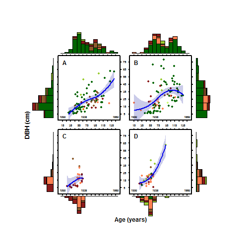

```r
    text(15,2,"1990", cex=0.8, font=2)
    text(145, 2, "1860", cex=0.8, font=2)
    text(67, 2, "1938", cex=0.8, font=2)
```

```r
#dev.off()
```

Enviromental data - ms. Figure 7 now Figure 4

Read in data from a variety of sources:

Climate data: Amherst, MA 1893-2012 (http://www.ncdc.noaa.gov/cdo.web); 1896 is missing!!!

PDSI 481 - 2003 (http://www.ncdc.noaa.gov/paleo/pdsidata.html)

population data from HF1980-13 and US Census bureau

Harvard Forest climate data

```r
hf.Shaler <- read.csv("C:/Users/aellison/Dropbox/Aaron's Briefcase/manuscript - Simes dendro and land use/env data/hf000-01-daily-m.csv",
    header = TRUE)

head(hf.Shaler)
```

```
##       Date AirT AirTmax AirTmin Prec
## 1 1/1/1964  -14      -6     -21  0.0
## 2 1/2/1964   -7       0     -14  6.4
## 3 1/3/1964   -2       1      -4  0.0
## 4 1/4/1964    2       6      -2  0.0
## 5 1/5/1964    0       4      -4  0.0
## 6 1/6/1964   -6       1     -12  0.0
```

```r
summary(hf.Shaler)
```

```
##        Date            AirT          AirTmax         AirTmin
##  1/1/1964:    1   Min.   :-24.0   Min.   :-20.0   Min.   :-33.0
##  1/1/1965:    1   1st Qu.: -1.0   1st Qu.:  4.0   1st Qu.: -6.0
##  1/1/1966:    1   Median :  8.0   Median : 14.0   Median :  2.0
##  1/1/1967:    1   Mean   :  7.3   Mean   : 13.1   Mean   :  1.5
##  1/1/1968:    1   3rd Qu.: 16.0   3rd Qu.: 23.0   3rd Qu.: 10.0
##  1/1/1969:    1   Max.   : 28.0   Max.   : 36.0   Max.   : 24.0
##  (Other) :14055   NA's   :489     NA's   :288     NA's   :384
##       Prec
##  Min.   :  0.00
##  1st Qu.:  0.00
##  Median :  0.00
##  Mean   :  3.01
##  3rd Qu.:  1.50
##  Max.   :119.40
##  NA's   :148
```

```r
str(hf.Shaler)
```

```
## 'data.frame':    14061 obs. of  5 variables:
##  $ Date   : Factor w/ 14061 levels "1/1/1964","1/1/1965",..: 1 430 859 976 1015 1054 1093 1132 1171 40 ...
##  $ AirT   : int  -14 -7 -2 2 0 -6 -1 -5 -6 -4 ...
##  $ AirTmax: int  -6 0 1 6 4 1 4 3 -1 1 ...
##  $ AirTmin: int  -21 -14 -4 -2 -4 -12 -6 -12 -11 -9 ...
##  $ Prec   : num  0 6.4 0 0 0 0 0 0 10.2 0 ...
```

```r
hf.Shaler$Date <- as.character(hf.Shaler$Date)

a <- as.Date(hf.Shaler$Date, "%m/%d/%Y")

hf.Shaler <- cbind(a, hf.Shaler)
names(hf.Shaler)[1] <- "date"
head(hf.Shaler)
```

```
##         date     Date AirT AirTmax AirTmin Prec
## 1 1964-01-01 1/1/1964  -14      -6     -21  0.0
## 2 1964-01-02 1/2/1964   -7       0     -14  6.4
## 3 1964-01-03 1/3/1964   -2       1      -4  0.0
## 4 1964-01-04 1/4/1964    2       6      -2  0.0
## 5 1964-01-05 1/5/1964    0       4      -4  0.0
## 6 1964-01-06 1/6/1964   -6       1     -12  0.0
```

```r
str(hf.Shaler)
```

```
## 'data.frame':    14061 obs. of  6 variables:
##  $ date   : Date, format: "1964-01-01" "1964-01-02" ...
##  $ Date   : chr  "1/1/1964" "1/2/1964" "1/3/1964" "1/4/1964" ...
##  $ AirT   : int  -14 -7 -2 2 0 -6 -1 -5 -6 -4 ...
##  $ AirTmax: int  -6 0 1 6 4 1 4 3 -1 1 ...
##  $ AirTmin: int  -21 -14 -4 -2 -4 -12 -6 -12 -11 -9 ...
##  $ Prec   : num  0 6.4 0 0 0 0 0 0 10.2 0 ...
```

```r
hf.Fisher <- read.csv("C:/Users/aellison/Dropbox/Aaron's Briefcase/manuscript - Simes dendro and land use/env data/hf001-02-annual-m.csv",
    header = TRUE)

Fisher.2002 <- hf.Fisher[1:2, c(2, 3, 4, 7)]
```

```r
Shaler.temps <- aggregate(hf.Shaler[, 3:5], list(year = cut(hf.Shaler$date,
    "years", right = TRUE)), mean, na.rm = TRUE)

Shaler.precip <- aggregate(hf.Shaler[, 6], list(year = cut(hf.Shaler$date, "years",
    right = TRUE)), sum, na.rm = TRUE)

Shaler.annual <- merge(Shaler.temps, Shaler.precip)
names(Shaler.annual)[5] <- "Precip"

HF.annual <- Shaler.annual
HF.annual$year <- as.character(HF.annual$year)
HF.annual[39:40, 2:5] <- Fisher.2002[, 1:4]
HF.annual[40, 1] <- "2003-01-01"
HF.annual
```

```
##          year  AirT AirTmax  AirTmin Precip
## 1  1964-01-01 7.050   13.32  0.78779  689.2
## 2  1965-01-01 7.269   13.17  0.95251  622.1
## 3  1966-01-01 6.857   13.11  0.61157  806.1
## 4  1967-01-01 6.319   12.11  0.57534 1119.7
## 5  1968-01-01 6.638   12.55  0.72981  883.7
## 6  1969-01-01 7.039   12.59  1.54270 1014.0
## 7  1970-01-01 6.371   12.13  0.68000  866.3
## 8  1971-01-01 6.888   12.66  1.15890  993.5
## 9  1972-01-01 6.449   11.56  1.25344 1266.1
## 10 1973-01-01 8.208   13.72  2.70083 1198.4
## 11 1974-01-01 6.964   12.58  1.39452 1082.6
## 12 1975-01-01 7.540   13.05  2.00000 1349.8
## 13 1976-01-01 6.598   12.31  0.96175 1113.6
## 14 1977-01-01 7.168   12.51  1.80495 1289.8
```

[output cut: 26 more lines]

Amherst climate data

```r
amherst <- read.csv("C:/Users/aellison/Dropbox/Aaron's Briefcase/manuscript - Simes dendro and land use/env data/Amherst_met_1893-2012-reduced.csv",
    header = TRUE)

amherst$AirT <- apply(amherst[, 10:11], 1, mean)
amherst.temps <- aggregate(amherst[, c(10, 11, 25)], by = list(year = amherst$YEAR),
    mean, na.rm = TRUE)

amherst.precip <- aggregate(amherst[, 7], by = list(year = amherst$YEAR), sum,
    na.rm = TRUE)

amherst.annual <- merge(amherst.temps, amherst.precip)
names(amherst.annual)[2:5] <- c("AirTmax", "AirTmin", "AirT", "Precip")

# rescale to deg C and mm as ncdc data are in tenths
amherst.annual[, 2:5] <- amherst.annual[, 2:5]/10

head(amherst.annual)
```

```
##   year AirTmax AirTmin  AirT Precip
## 1 1893   13.38   1.610 7.507 1038.4
## 2 1894   14.73   2.934 8.818  791.1
## 3 1895   14.14   2.088 8.092 1031.1
## 4 1897   13.66   2.137 7.910 1259.7
## 5 1898   14.71   3.612 9.215 1285.9
## 6 1899   14.11   2.720 8.389 1056.9
```

```r
# need to add in missing year for 1896)
amherst.annual.fixed <- amherst.annual
amherst.annual.fixed[5:121, ] <- amherst.annual[4:120, ]
amherst.annual.fixed[4, ] <- c(1896, NA, NA, NA, NA)
head(amherst.annual.fixed)
```

```
##   year AirTmax AirTmin  AirT Precip
## 1 1893   13.38   1.610 7.507 1038.4
## 2 1894   14.73   2.934 8.818  791.1
## 3 1895   14.14   2.088 8.092 1031.1
## 4 1896      NA      NA    NA     NA
## 5 1897   13.66   2.137 7.910 1259.7
## 6 1898   14.71   3.612 9.215 1285.9
```

```r
dim(amherst.annual.fixed)
```

```
## [1] 121   5
```

Palmer Drought Severity Index, station 267 (72.5 W, 42.5 N = near Leverett, MA. Data) from

```r
leverett.pdsi <- read.csv("C:/Users/aellison/Dropbox/Aaron's Briefcase/manuscript - Simes dendro and land use/env data/PDSO - 267.csv",
    header = TRUE)

head(leverett.pdsi)
```

```
##   YEAR NREC NCRN  RECON  X20LP  CRSQ  VRSQ    RE    CE  ACT X20LP.1
## 1  481    1    1 -1.737 -0.585 0.106 0.284 0.234 0.134 -100    -100
## 2  482    1    1  2.334 -0.631 0.106 0.284 0.234 0.134 -100    -100
## 3  483    1    1 -1.308 -0.684 0.106 0.284 0.234 0.134 -100    -100
## 4  484    1    1 -0.723 -0.732 0.106 0.284 0.234 0.134 -100    -100
## 5  485    1    1 -1.770 -0.761 0.106 0.284 0.234 0.134 -100    -100
## 6  486    1    1 -0.708 -0.763 0.106 0.284 0.234 0.134 -100    -100
```

```r
summary(leverett.pdsi)
```

```
##       YEAR           NREC             NCRN            RECON
##  Min.   : 481   Min.   :-99.00   Min.   :-99.00   Min.   :-4.450
##  1st Qu.: 862   1st Qu.:  1.00   1st Qu.:  1.00   1st Qu.:-1.258
##  Median :1242   Median :  2.00   Median :  3.00   Median :-0.261
##  Mean   :1242   Mean   :  2.53   Mean   :  7.16   Mean   :-0.192
##  3rd Qu.:1622   3rd Qu.:  7.00   3rd Qu.:  9.00   3rd Qu.: 0.810
##  Max.   :2003   Max.   :  7.00   Max.   : 29.00   Max.   : 4.070
##      X20LP             CRSQ              VRSQ               RE
##  Min.   :-1.893   Min.   :-100.00   Min.   :-100.00   Min.   :-100.00
##  1st Qu.:-0.606   1st Qu.:   0.11   1st Qu.:   0.28   1st Qu.:   0.23
##  Median :-0.178   Median :   0.20   Median :   0.31   Median :   0.26
##  Mean   :-0.192   Mean   :  -1.41   Mean   :  -1.30   Mean   :  -1.33
##  3rd Qu.: 0.182   3rd Qu.:   0.36   3rd Qu.:   0.42   3rd Qu.:   0.42
##  Max.   : 1.427   Max.   :   0.43   Max.   :   0.44   Max.   :   0.43
##        CE               ACT             X20LP.1
##  Min.   :-100.00   Min.   :-100.00   Min.   :-100.00
##  1st Qu.:   0.13   1st Qu.:-100.00   1st Qu.:-100.00
##  Median :   0.16   Median :-100.00   Median :-100.00
##  Mean   :  -1.39   Mean   : -93.17   Mean   : -93.17
##  3rd Qu.:   0.40   3rd Qu.:-100.00   3rd Qu.:-100.00
##  Max.   :   0.42   Max.   :   3.25   Max.   :   0.97
```

population data

```r
pop.data <- read.csv("C:/Users/aellison/Dropbox/Aaron's Briefcase/manuscript - Simes dendro and land use/env data/phampop.csv")
```

rework these into time-series objects and plot to check

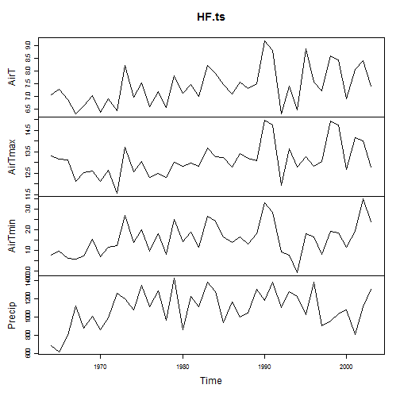

```r
HF.ts <- ts(data = HF.annual[, 2:5], start = 1964, frequency = 1)
plot(HF.ts)
```

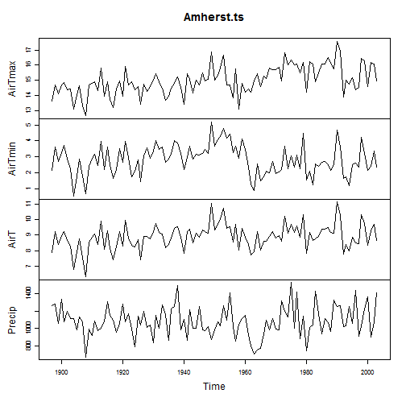

```r
Amherst.ts <- ts(data = amherst.annual.fixed[-(1:4), 2:5], start = 1897, end = 2003,
    frequency = 1)
plot(Amherst.ts)
```

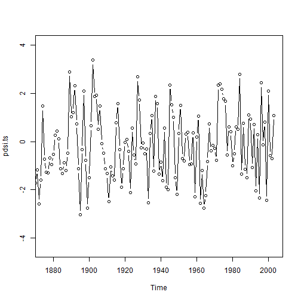

```r
pdsi.ts <- ts(data = leverett.pdsi$RECON, start = 481, frequency = 1)
plot(pdsi.ts, type = "b", xlim = c(1875, 2003))
```

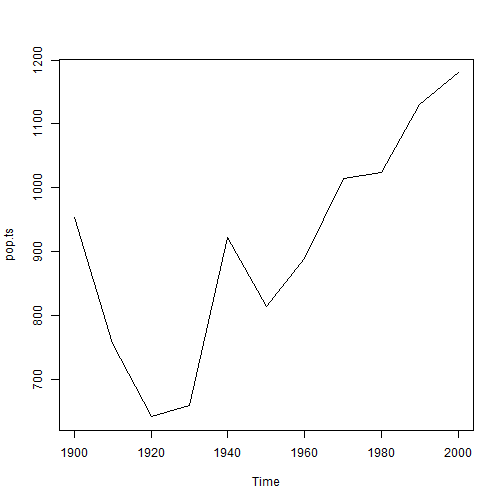

```r
pop.ts <- ts(data = pop.data$popn, start = 1900, frequency = 0.1)
plot(pop.ts)
```

build a nice plot

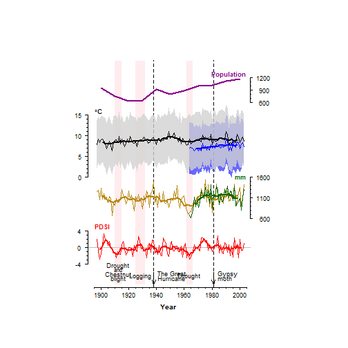

```r
# pdf('Simes_environment_v3.pdf', width=4, height=6, pointsize=8)
par(las = 1, mar = c(0, 0, 0, 1) + 0.1, fin = c(3.5, 4.6), yaxs = "r")
ylimits <- c(min(pdsi.ts) - 4.75, max(Amherst.ts[, 1]) + 22)
out.limits <- ylimits * 1.04

plot(Amherst.ts[, 3], ylim = out.limits, xlim = c(1895, 2003), type = "n", axes = FALSE,
    xlab = "", ylab = "")

abline(h = -2, lty = 1, lwd = 1, col = "gray")
# abline(v=1911, lty=2, lwd=1, col='black') Removed blight for rectangle
abline(v = 1938, lty = 2, lwd = 1, col = "black")
abline(v = 1981, lty = 2, lwd = 1, col = "black")
rect(1910, -11, 1915, 43, col = rgb(255, 192, 203, alpha = 75, max = 255), lty = 0,
    lwd = 0)  #Chestnut blight
rect(1925, -11, 1932, 43, col = rgb(255, 192, 203, alpha = 75, max = 255), lty = 0,
    lwd = 0)  #1925-32 logging
rect(1962, -11, 1966, 43, col = rgb(255, 192, 203, alpha = 75, max = 255), lty = 0,
    lwd = 0)  #1960s drought
# abline(v=1918, lty=2, lwd=1, col='black') Removed WPBR


lines(pop.ts/100 + 27, lwd = 2, col = "magenta4")

polygon(c(seq(1964, 2003, 1), seq(2003, 1964, -1)), c(HF.ts[, 3] + 15, rev(HF.ts[,
    2] + 15)), col = rgb(0, 0, 255, alpha = 150, max = 255), lty = 0)

polygon(c(seq(1897, 2003, 1), seq(2003, 1897, -1)), c(Amherst.ts[, 1] + 15,
    rev(Amherst.ts[, 2] + 15)), col = rgb(210, 210, 210, alpha = 200, max = 255),
    lty = 0)

lines(rollapply(Amherst.ts[, 3], 10, mean) + 15, lty = 1, lwd = 2)
lines(Amherst.ts[, 3] + 15, lty = 1, lwd = 1)

lines(rollapply(HF.ts[, 1], 10, mean) + 15, lty = 1, lwd = 2, col = "blue")
lines(HF.ts[, 1] + 15, col = "blue", lty = 1, lwd = 1)

lines(rollapply(Amherst.ts[, 4]/100, 10, mean) - 1, lty = 1, lwd = 2, col = "darkgoldenrod")
lines(Amherst.ts[, 4]/100 - 1, lwd = 1, col = "darkgoldenrod")

lines(rollapply(HF.ts[, 4]/100, 10, mean) - 1, lty = 1, lwd = 2, col = "darkgreen")
lines(HF.ts[, 4]/100 - 1, lwd = 1, col = "darkgreen")

lines(rollapply(window(pdsi.ts, 1897, 2003), 5, mean) - 2, lty = 1, lwd = 2,
    col = "red")
lines(window(pdsi.ts, 1897, 2003) - 2, lty = 1, lwd = 1, col = "red")




axis(1, tcl = -0.25, font = 1, padj = -1.5, cex.axis = 0.75)
axis(1, tcl = -0.125, at = seq(1895, 2005, 5), labels = FALSE)
axis(2, tcl = -0.25, at = seq(15, 30, 5), labels = c("  0", "  5", "10", "15"),
    font = 1, hadj = 0.5, cex.axis = 0.75)
axis(2, tcl = -0.125, at = seq(15, 30, 1), labels = FALSE)

axis(4, tcl = -0.25, at = seq(33, 39, 3), labels = c(" 600", " 900", "1200"),
    font = 1, cex.axis = 0.75, hadj = 0.25)
axis(4, tcl = -0.125, at = seq(33, 39, 1), labels = FALSE)

axis(4, tcl = -0.25, at = seq(5, 15, 5), labels = c("  600", "1100", "1600"),
    font = 1, cex.axis = 0.75, hadj = 0.25)
axis(4, tcl = -0.125, at = seq(5, 15, 1), labels = FALSE)

axis(2, tcl = -0.25, at = seq(-6, 2, 4), font = 1, labels = c("-4", " 0", " 4"),
    hadj = 0.5, cex.axis = 0.75)
axis(2, tcl = -0.125, at = seq(-6, 2, 1), labels = FALSE)

text(1892, 31, expression(bold(paste(degree, "C"))), pos = 4, cex = 0.75, font = 2)
text(1892, 3, "PDSI", pos = 4, cex = 0.75, font = 2, col = "red")
text(2008, 15, "mm", pos = 2, cex = 0.75, font = 2, col = "darkgreen")
text(2008, 40, "Population", pos = 2, cex = 0.75, font = 2, col = "magenta4")

mtext(side = 1, "Year", padj = 2.5, cex = 0.85, font = 2)


arrows(x0 = 1938, y0 = -8, y1 = -11, lwd = 1, angle = 20, length = 0.1)
text(1937.5, -8.25, "The Great", pos = 4, cex = 0.75)
text(1937.5, -9.5, "Hurricane", pos = 4, cex = 0.75)
arrows(x0 = 1981, y0 = -8, y1 = -11, lwd = 1, angle = 20, length = 0.1)
text(1980.5, -8.25, "Gypsy", pos = 4, cex = 0.75)
text(1980.5, -9.5, "moth", pos = 4, cex = 0.75)

# segments(1925, -10, 1932, -10, lty=1, lwd=2)
text(1928.5, -8.875, "Logging", cex = 0.75)

# arrows(x0=1911, y0=-8, y1=-11, lwd=1, angle=20, length=.1)
text(1912.5, -6.25, "Drought", cex = 0.75)
text(1912.5, -7.25, "and", cex = 0.65)
text(1912.5, -8.25, "Chestnut", cex = 0.75)
text(1912.5, -9.5, "blight", cex = 0.75)


text(1964, -8.875, "Drought", cex = 0.75)
```

```r
# dev.off()
```

Some analysis

```r
# mean temps

apply(Amherst.ts, 2, mean)
```

```
##  AirTmax  AirTmin     AirT   Precip
##   14.991    2.815    8.901 1084.090
```

```r
apply(HF.ts, 2, mean)
```

```
##     AirT  AirTmax  AirTmin   Precip
##    7.395   13.116    1.568 1095.010
```

```r
# average annual difference in temperatures
mean(window(Amherst.ts[, 3], start = 1964) - HF.ts[, 1])
```

```
## [1] 1.687
```

```r
mean(window(pdsi.ts, 1897, 2003))
```

```
## [1] -0.09738
```

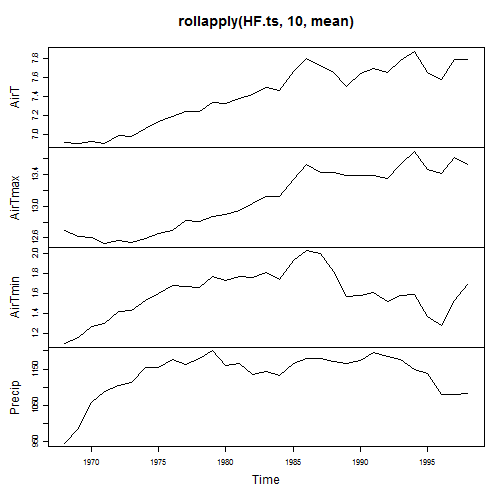

```r
# running means
plot(rollapply(HF.ts, 10, mean))
```

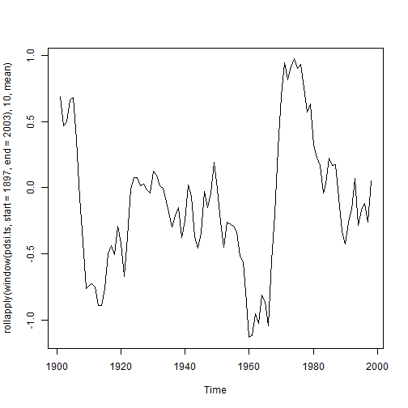

```r
plot(rollapply(window(pdsi.ts, start = 1897, end = 2003), 10, mean))
```

```r
# compare HF and Amherst data during period of overlap

cor.test(as.vector(window(Amherst.ts[, 3], start = 1964)), as.vector(HF.ts[,
    1]))
```

```
##
##  Pearson's product-moment correlation
##
## data:  as.vector(window(Amherst.ts[, 3], start = 1964)) and as.vector(HF.ts[, 1])
## t = 5.502, df = 38, p-value = 2.746e-06
## alternative hypothesis: true correlation is not equal to 0
## 95 percent confidence interval:
##  0.4471 0.8095
## sample estimates:
##    cor
## 0.6659
```

```r
lm(as.vector(HF.ts[, 1]) ~ as.vector(window(Amherst.ts[, 3], start = 1964)))
```

```
##
## Call:
## lm(formula = as.vector(HF.ts[, 1]) ~ as.vector(window(Amherst.ts[,
##     3], start = 1964)))
##
## Coefficients:
##                                      (Intercept)
##                                            1.187
## as.vector(window(Amherst.ts[, 3], start = 1964))
##                                            0.684
```

```r
cor.test(as.vector(window(Amherst.ts[, 4], start = 1964)), as.vector(HF.ts[,
    4]))
```

```
##
##  Pearson's product-moment correlation
##
## data:  as.vector(window(Amherst.ts[, 4], start = 1964)) and as.vector(HF.ts[, 4])
## t = 8.8, df = 38, p-value = 1.052e-10
## alternative hypothesis: true correlation is not equal to 0
## 95 percent confidence interval:
##  0.6814 0.9007
## sample estimates:
##   cor
## 0.819
```

```r
lm(as.vector(HF.ts[, 4]) ~ as.vector(window(Amherst.ts[, 4], start = 1964)))
```

```
##
## Call:
## lm(formula = as.vector(HF.ts[, 4]) ~ as.vector(window(Amherst.ts[,
##     4], start = 1964)))
##
## Coefficients:
##                                      (Intercept)
##                                          182.295
## as.vector(window(Amherst.ts[, 4], start = 1964))
##                                            0.824
```

Add age, radius, and BAI to dendro

```r
den <- dendro
Age <- NULL
Radius <- NULL
for (n in unique(den$TreeNum)) {
    hold <- den[den$TreeNum == n, ]
    Age <- c(Age, hold$Year - min(hold$Year))
    Radius <- c(Radius, cumsum(hold$mmperyear))
}

BAI <- (pi * Radius^2) - (pi * (Radius - den$mmperyear)^2)

gpyr <- 1865 + (den$Year - 1861)%/%5 * 5

GenSpec <- paste(den$Genus, den$Species)

den <- data.frame(den, GenSpec, gpyr, Age, Radius, BAI)

birthyr.table <- tapply(den$Year, list(den$TreeNum), min)
birthyr.TreeNum <- as.numeric(names(birthyr.table))
birthyr.Year <- as.integer(birthyr.table)
birthyr <- data.frame(birthyr.TreeNum, birthyr.Year)
names(birthyr) <- c("TreeNum", "Byear")

for (n in unique(den$TreeNum)) {
    len <- length(den[den$Treenum == n, 1])
    den$Byear[den$TreeNum == n] <- rep(birthyr$Byear[birthyr$TreeNum == n],
        len)
}

dendro.raw <- den

# add blocks and canopy as factors, and level in correct order;

dendro.raw$block <- ifelse(dendro.raw$Plot > 3 & dendro.raw$Plot < 8, "Ridge",
    "Valley")

dendro.raw$block <- as.factor(dendro.raw$block)

dendro.raw$canopy <- ifelse(dendro.raw$Plot < 7, "Hemlock", "Hardwood")
dendro.raw$canopy <- as.factor(dendro.raw$canopy)

dendro.raw$block <- relevel(dendro.raw$block, ref = "Valley")
dendro.raw$canopy <- relevel(dendro.raw$canopy, ref = "Hemlock")

dendro.raw$TreeNum <- as.factor(dendro.raw$TreeNum)

head(dendro.raw)
```

```
##   Plot Genus Species Code TreeNum Year mmperyear     GenSpec gpyr Age
## 1    1  Acer  rubrum ACRU     532 1935     1.275 Acer rubrum 1935   0
## 2    1  Acer  rubrum ACRU     532 1936     1.519 Acer rubrum 1940   1
## 3    1  Acer  rubrum ACRU     532 1937     1.375 Acer rubrum 1940   2
## 4    1  Acer  rubrum ACRU     532 1938     0.891 Acer rubrum 1940   3
## 5    1  Acer  rubrum ACRU     532 1939     0.737 Acer rubrum 1940   4
## 6    1  Acer  rubrum ACRU     532 1940     1.139 Acer rubrum 1940   5
##   Radius    BAI  block  canopy
## 1  1.275  5.107 Valley Hemlock
## 2  2.794 19.418 Valley Hemlock
## 3  4.169 30.078 Valley Hemlock
## 4  5.060 25.833 Valley Hemlock
## 5  5.797 25.138 Valley Hemlock
## 6  6.936 45.562 Valley Hemlock
```

```r
dim(dendro.raw)
```

```
## [1] 17199    14
```

```r
str(dendro.raw)
```

```
## 'data.frame':    17199 obs. of  14 variables:
##  $ Plot     : int  1 1 1 1 1 1 1 1 1 1 ...
##  $ Genus    : Factor w/ 7 levels "Acer","Betula",..: 1 1 1 1 1 1 1 1 1 1 ...
##  $ Species  : Factor w/ 13 levels "alba","allegheniensis",..: 9 9 9 9 9 9 9 9 9 9 ...
##  $ Code     : Factor w/ 12 levels "ACRU","ACSA",..: 1 1 1 1 1 1 1 1 1 1 ...
##  $ TreeNum  : Factor w/ 230 levels "3","5","9","11",..: 158 158 158 158 158 158 158 158 158 158 ...
##  $ Year     : int  1935 1936 1937 1938 1939 1940 1941 1942 1943 1944 ...
##  $ mmperyear: num  1.275 1.519 1.375 0.891 0.737 ...
##  $ GenSpec  : Factor w/ 13 levels "Acer rubrum",..: 1 1 1 1 1 1 1 1 1 1 ...
##  $ gpyr     : num  1935 1940 1940 1940 1940 ...
##  $ Age      : int  0 1 2 3 4 5 6 7 8 9 ...
##  $ Radius   : num  1.27 2.79 4.17 5.06 5.8 ...
##  $ BAI      : num  5.11 19.42 30.08 25.83 25.14 ...
##  $ block    : Factor w/ 2 levels "Valley","Ridge": 1 1 1 1 1 1 1 1 1 1 ...
##  $ canopy   : Factor w/ 2 levels "Hemlock","Hardwood": 1 1 1 1 1 1 1 1 1 1 ...
```

Reduce to 5 key species; reorder factors:

```r
dendro.5sp <- dendro.raw[dendro.raw$Code == "TSCA" | dendro.raw$Code == "ACRU" |
    dendro.raw$Code == "BELE" | dendro.raw$Code == "QURU" | dendro.raw$Code ==
    "PIST", ]

dendro.5sp <- droplevels(dendro.5sp)
dendro.5sp$Code <- reorder(dendro.5sp$Code, new.order = c(5, 2, 4, 1, 3))
dendro.5sp$Code <- factor(dendro.5sp$Code, labels = c("Tsuga", "Betula", "Quercus",
    "Acer", "Pinus"))

# relative BAI

dendro.5sp$rBAI <- ((pi * dendro.5sp$Radius^2) - pi * (dendro.5sp$Radius - dendro.5sp$mmperyear)^2)/(dendro.5sp$Radius -
    dendro.5sp$mmperyear)

dendro.5sp$rBAI[dendro.5sp$rBAI == Inf] <- NA

# pad the few 0s for log plotting

dendro.5sp$rBAI[dendro.5sp$rBAI == 0] <- 1e-04

head(dendro.5sp)
```

```
##   Plot Genus Species Code TreeNum Year mmperyear     GenSpec gpyr Age
## 1    1  Acer  rubrum Acer     532 1935     1.275 Acer rubrum 1935   0
## 2    1  Acer  rubrum Acer     532 1936     1.519 Acer rubrum 1940   1
## 3    1  Acer  rubrum Acer     532 1937     1.375 Acer rubrum 1940   2
## 4    1  Acer  rubrum Acer     532 1938     0.891 Acer rubrum 1940   3
## 5    1  Acer  rubrum Acer     532 1939     0.737 Acer rubrum 1940   4
## 6    1  Acer  rubrum Acer     532 1940     1.139 Acer rubrum 1940   5
##   Radius    BAI  block  canopy   rBAI
## 1  1.275  5.107 Valley Hemlock     NA
## 2  2.794 19.418 Valley Hemlock 15.229
## 3  4.169 30.078 Valley Hemlock 10.765
## 4  5.060 25.833 Valley Hemlock  6.197
## 5  5.797 25.138 Valley Hemlock  4.968
## 6  6.936 45.562 Valley Hemlock  7.860
```

```r
str(dendro.5sp)
```

```
## 'data.frame':    15919 obs. of  15 variables:
##  $ Plot     : int  1 1 1 1 1 1 1 1 1 1 ...
##  $ Genus    : Factor w/ 5 levels "Acer","Betula",..: 1 1 1 1 1 1 1 1 1 1 ...
##  $ Species  : Factor w/ 6 levels "canadensis","candensis",..: 5 5 5 5 5 5 5 5 5 5 ...
##  $ Code     : Factor w/ 5 levels "Tsuga","Betula",..: 4 4 4 4 4 4 4 4 4 4 ...
##  $ TreeNum  : Factor w/ 212 levels "3","5","9","11",..: 145 145 145 145 145 145 145 145 145 145 ...
##  $ Year     : int  1935 1936 1937 1938 1939 1940 1941 1942 1943 1944 ...
##  $ mmperyear: num  1.275 1.519 1.375 0.891 0.737 ...
##  $ GenSpec  : Factor w/ 6 levels "Acer rubrum",..: 1 1 1 1 1 1 1 1 1 1 ...
##  $ gpyr     : num  1935 1940 1940 1940 1940 ...
##  $ Age      : int  0 1 2 3 4 5 6 7 8 9 ...
##  $ Radius   : num  1.27 2.79 4.17 5.06 5.8 ...
##  $ BAI      : num  5.11 19.42 30.08 25.83 25.14 ...
##  $ block    : Factor w/ 2 levels "Valley","Ridge": 1 1 1 1 1 1 1 1 1 1 ...
##  $ canopy   : Factor w/ 2 levels "Hemlock","Hardwood": 1 1 1 1 1 1 1 1 1 1 ...
##  $ rBAI     : num  NA 15.23 10.77 6.2 4.97 ...
```

Plots

Figure 9: Individual traces of rBAI as a function of year, with smoothers. Overlay hemlock and hardwood plots.

[output not shown]

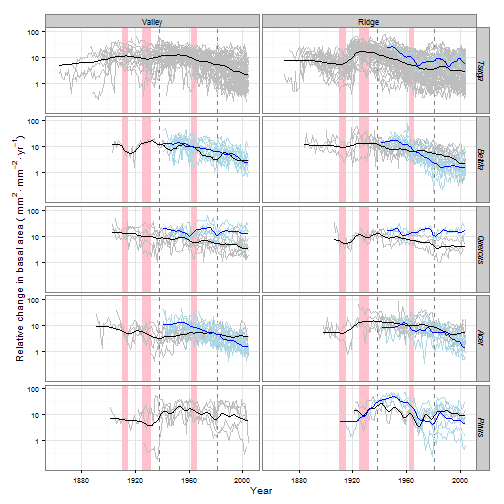

```r
# To create pdf, uncomment pdf and dev.off() lines.
# pdf('Figure-9-BAI-both-v2.pdf', width=4, height=6)

ggplot(data = dendro.5sp[dendro.5sp$canopy == "Hemlock", ], aes(x = Year, y = rBAI,
    group = TreeNum)) + facet_grid(Code ~ block) + scale_y_log10(limits = c(0.1,
    100), breaks = c(1, 10, 100)) + scale_x_continuous(limits = c(1860, 2005),
    breaks = c(seq(1880, 2000, 40))) +
# add environmental markers

geom_rect(xmin = 1910, xmax = 1915, ymin = -Inf, ymax = Inf, fill = "pink",
    alpha = 0.3, inherit.aes = FALSE) + geom_rect(xmin = 1925, xmax = 1932,
    ymin = -Inf, ymax = Inf, fill = "pink", alpha = 0.3, inherit.aes = FALSE) +
    geom_rect(xmin = 1962, xmax = 1966, ymin = -Inf, ymax = Inf, fill = "pink",
        alpha = 0.3, inherit.aes = FALSE) +
# geom_vline(xintercept=1911, color='grey50', linetype=2, size=.25) +
# geom_vline(xintercept=1918, color='grey50', linetype=2, size=.25) +
geom_vline(xintercept = 1938, color = "grey50", linetype = 2, size = 0.25) +
    geom_vline(xintercept = 1981, color = "grey50", linetype = 2, size = 0.25) +

geom_line(colour = "grey", size = 0.25) +
# add the hardwood plots in light blue

geom_line(data = dendro.5sp[dendro.5sp$canopy == "Hardwood", ], aes(x = Year,
    y = rBAI, group = TreeNum), colour = "lightblue", size = 0.25) +
# smoothers go next

# geom_smooth(se=FALSE, data=dendro.5sp[dendro.5sp$canopy=='Hemlock',],
# aes(group=1), method='loess', na.action=na.omit, span=.1, linetype=1,
# colour='black', weight=2) +

# geom_smooth(se=FALSE, data=dendro.5sp[dendro.5sp$canopy=='Hardwood',],
# aes(group=1), method='loess', na.action=na.omit, span=.1, linetype=1,
# colour='blue', weight=2) +

stat_smooth(se = FALSE, data = dendro.5sp[dendro.5sp$canopy == "Hemlock", ],
    aes(group = 1), method = "loess", degree = 0, na.action = na.omit, span = 0.1,
    linetype = 1, colour = "black", weight = 2) +

stat_smooth(se = FALSE, data = dendro.5sp[dendro.5sp$canopy == "Hardwood", ],
    aes(group = 1), method = "loess", degree = 0, na.action = na.omit, span = 0.1,
    linetype = 1, colour = "blue", weight = 2) +
theme_bw() + theme(strip.text.y = element_text(face = "italic", size = 8), strip.text.x = element_text(size = 8),
    axis.text = element_text(size = 7), axis.title = element_text(size = 10),
    axis.ticks.length = unit(1, "mm"), axis.ticks = element_line(size = 0.25)) +
    # ylab(expression(paste('Relative change in basal area (' mm^2 cdot mm^)
ylab(expression(paste("Relative change in basal area (", mm^2 %.% mm^-2 %.%
    yr^-1, ")")))
```

```r
# dev.off()
```

Fit 1-d GAMs

```r
gam.acer1 <- gam(rBAI ~ as.factor(Year) + s(Age, fx = TRUE, k = 4, bs = "cs"),
    data = subset(dendro.5sp, Code == "Acer"))
gam.betula1 <- gam(rBAI ~ as.factor(Year) + s(Age, fx = TRUE, k = 4, bs = "cs"),
    data = subset(dendro.5sp, Code == "Betula"))
gam.quercus1 <- gam(rBAI ~ as.factor(Year) + s(Age, fx = TRUE, k = 4, bs = "cs"),
    data = subset(dendro.5sp, Code == "Quercus"))
gam.pinus1 <- gam(rBAI ~ as.factor(Year) + s(Age, fx = TRUE, k = 4, bs = "cs"),
    data = subset(dendro.5sp, Code == "Pinus"))
gam.tsuga1 <- gam(rBAI ~ as.factor(Year) + s(Age, fx = TRUE, k = 4, bs = "cs"),
    data = subset(dendro.5sp, Code == "Tsuga"))


# get wiggly year effects


years.a <- c(min(dendro.5sp$Year[dendro.5sp$Code == "Acer"]):2004)
lastyr.a <- 2005 - min(dendro.5sp$Year[dendro.5sp$Code == "Acer" & dendro.5sp$Age ==
    0])
fixed.year.a <- c(gam.acer1$coef[1], gam.acer1$coef[1] + gam.acer1$coef[2:lastyr.a])


years.b <- c(min(dendro.5sp$Year[dendro.5sp$Code == "Betula"]):2004)
lastyr.b <- 2005 - min(dendro.5sp$Year[dendro.5sp$Code == "Betula" & dendro.5sp$Age ==
    0])
fixed.year.b <- c(gam.betula1$coef[1], gam.betula1$coef[1] + gam.betula1$coef[2:lastyr.b])

years.q <- c(min(dendro.5sp$Year[dendro.5sp$Code == "Quercus"]):2004)
lastyr.q <- 2005 - min(dendro.5sp$Year[dendro.5sp$Code == "Quercus" & dendro.5sp$Age ==
    0])
fixed.year.q <- c(gam.quercus1$coef[1], gam.quercus1$coef[1] + gam.quercus1$coef[2:lastyr.q])

years.p <- c(min(dendro.5sp$Year[dendro.5sp$Code == "Pinus"]):2004)
lastyr.p <- 2005 - min(dendro.5sp$Year[dendro.5sp$Code == "Pinus" & dendro.5sp$Age ==
    0])
fixed.year.p <- c(gam.pinus1$coef[1], gam.pinus1$coef[1] + gam.pinus1$coef[2:lastyr.p])

years.t <- c(min(dendro.5sp$Year[dendro.5sp$Code == "Tsuga"]):2004)
lastyr.t <- 2005 - min(dendro.5sp$Year[dendro.5sp$Code == "Tsuga" & dendro.5sp$Age ==
    0])
fixed.year.t <- c(gam.tsuga1$coef[1], gam.tsuga1$coef[1] + gam.tsuga1$coef[2:lastyr.t])
```

Nice 10-panel plot per Rhodora specs

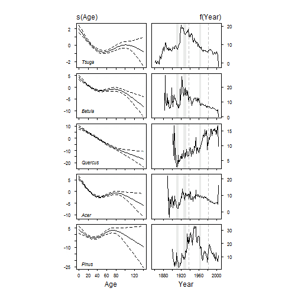

```r
# gam plots in first column remove comments on pdf() and dev.off() to
# generate pdf

# pdf('Figure_10-single-gams-v2.pdf', height=7, width=5, pointsize=9)

layout(matrix(c(1:10), 5, 2, byrow = FALSE), widths = rep(lcm(5), 2), heights = rep(lcm(3),
    5))
# layout.show(10)
par(mar = c(1, 2, 0, 0.5))
plot(gam.tsuga1, se = TRUE, xlab = "", ylab = "", xlim = c(0, 140), rug = FALSE,
    tcl = -0.25, col.axis = "white")
axis(2, las = 1, tcl = -0.25, at = c(-2, 0, 2))
text(0, -2, "Tsuga", font = 3, pos = 4)
mtext(side = 3, "s(Age)", adj = 0, line = 0.5, cex = 1)


plot(gam.betula1, se = TRUE, xlab = "", ylab = "", xlim = c(0, 140), rug = FALSE,
    tcl = -0.25, col.axis = "white")
axis(2, las = 1, tcl = -0.25, at = seq(-10, 5, 5))
text(0, -10, "Betula", font = 3, pos = 4)

plot(gam.quercus1, se = TRUE, xlab = "", ylab = "", xlim = c(0, 140), rug = FALSE,
    tcl = -0.25, col.axis = "white")
axis(2, las = 1, tcl = -0.25, at = seq(-20, 10, 10))
text(0, -20, "Quercus", font = 3, pos = 4)

plot(gam.acer1, se = TRUE, xlab = "", ylab = "", xlim = c(0, 140), rug = FALSE,
    tcl = -0.25, col.axis = "white")
axis(2, las = 1, tcl = -0.25, at = seq(-10, 5, 5))
text(0, -10, "Acer", font = 3, pos = 4)

plot(gam.pinus1, se = TRUE, xlab = "Age", ylab = "", xlim = c(0, 140), rug = FALSE,
    tcl = -0.25, col.axis = "white")
axis(2, las = 1, tcl = -0.25, at = seq(-25, 5, 15))
axis(1, tcl = -0.25, padj = -0.5)
text(0, -23, "Pinus", font = 3, pos = 4)
mtext(side = 1, "Age", , line = 2.25, cex = 1)


# age wiggles in 2nd column

par(mar = c(1, 0.5, 0, 2))
plot(years.t, fixed.year.t, type = "n", xlab = "", ylab = "", xlim = c(1860,
    2005), col.axis = "white", tcl = 0)
abline(v = c(1938, 1981), lty = 2, col = "grey")
rect(1910, -11, 1915, 43, col = rgb(190, 190, 190, alpha = 75, max = 255), lty = 0,
    lwd = 0)  #Chestnut blight
rect(1925, -11, 1932, 43, col = rgb(190, 190, 190, alpha = 75, max = 255), lty = 0,
    lwd = 0)  #1925-32 logging
rect(1962, -11, 1966, 43, col = rgb(190, 190, 190, alpha = 75, max = 255), lty = 0,
    lwd = 0)  #1960s drought
lines(years.t, fixed.year.t)
axis(1, tcl = -0.25, at = seq(1860, 2000, 20), labels = FALSE)
axis(4, tcl = -0.25, at = seq(0, 20, 10), las = 1)
mtext(side = 3, "f(Year)", adj = 1, line = 0.5, cex = 1)
box()


plot(years.b, fixed.year.b, type = "n", xlab = "", ylab = "", xlim = c(1860,
    2005), col.axis = "white", tcl = 0)
abline(v = c(1938, 1981), lty = 2, col = "grey")
rect(1910, -11, 1915, 43, col = rgb(190, 190, 190, alpha = 75, max = 255), lty = 0,
    lwd = 0)  #Chestnut blight
rect(1925, -11, 1932, 43, col = rgb(190, 190, 190, alpha = 75, max = 255), lty = 0,
    lwd = 0)  #1925-32 logging
rect(1962, -11, 1966, 43, col = rgb(190, 190, 190, alpha = 75, max = 255), lty = 0,
    lwd = 0)  #1960s drought
lines(years.b, fixed.year.b)
axis(1, tcl = -0.25, at = seq(1860, 2000, 20), labels = FALSE)
axis(4, tcl = -0.25, at = seq(0, 20, 10), las = 1)
box()


plot(years.q, fixed.year.q, type = "n", xlab = "", ylab = "", xlim = c(1860,
    2005), col.axis = "white", tcl = 0)
abline(v = c(1938, 1981), lty = 2, col = "grey")
rect(1910, -11, 1915, 43, col = rgb(190, 190, 190, alpha = 75, max = 255), lty = 0,
    lwd = 0)  #Chestnut blight
rect(1925, -11, 1932, 43, col = rgb(190, 190, 190, alpha = 75, max = 255), lty = 0,
    lwd = 0)  #1925-32 logging
rect(1962, -11, 1966, 43, col = rgb(190, 190, 190, alpha = 75, max = 255), lty = 0,
    lwd = 0)  #1960s drought
lines(years.q, fixed.year.q)
axis(1, tcl = -0.25, at = seq(1860, 2000, 20), labels = FALSE)
axis(4, tcl = -0.25, at = seq(5, 15, 5), las = 1)
box()

plot(years.a, fixed.year.a, type = "n", xlab = "", ylab = "", xlim = c(1860,
    2005), col.axis = "white", tcl = 0)
abline(v = c(1938, 1981), lty = 2, col = "grey")
rect(1910, -11, 1915, 43, col = rgb(190, 190, 190, alpha = 75, max = 255), lty = 0,
    lwd = 0)  #Chestnut blight
rect(1925, -11, 1932, 43, col = rgb(190, 190, 190, alpha = 75, max = 255), lty = 0,
    lwd = 0)  #1925-32 logging
rect(1962, -11, 1966, 43, col = rgb(190, 190, 190, alpha = 75, max = 255), lty = 0,
    lwd = 0)  #1960s drought
lines(years.a, fixed.year.a)
axis(1, tcl = -0.25, at = seq(1860, 2000, 20), labels = FALSE)
axis(4, tcl = -0.25, at = seq(0, 20, 10), las = 1)
box()


plot(years.p, fixed.year.p, type = "n", xlab = "", ylab = "", xlim = c(1860,
    2005), col.axis = "white", tcl = 0)
abline(v = c(1938, 1981), lty = 2, col = "grey")
rect(1910, -11, 1915, 43, col = rgb(190, 190, 190, alpha = 75, max = 255), lty = 0,
    lwd = 0)  #Chestnut blight
rect(1925, -11, 1932, 43, col = rgb(190, 190, 190, alpha = 75, max = 255), lty = 0,
    lwd = 0)  #1925-32 logging
rect(1962, -11, 1966, 43, col = rgb(190, 190, 190, alpha = 75, max = 255), lty = 0,
    lwd = 0)  #1960s drought
lines(years.p, fixed.year.p)
axis(1, tcl = -0.25, at = seq(1860, 2000, 20), labels = FALSE)
axis(1, tcl = 0, at = seq(1880, 2000, 40), padj = -0.5)
axis(4, tcl = -0.25, at = seq(10, 30, 10), las = 1)
mtext(side = 1, "Year", line = 2.25, cex = 1)
box()
```

```r
# dev.off()
```

Fit 2D-GAMS

```r
# pad the few 0s for log plotting

dendro.5sp$rBAI[dendro.5sp$rBAI == 0] <- 1e-04
# add birth year (Byear) to dendro.5sp

birthyr.table <- tapply(dendro.5sp$Year, list(dendro.5sp$TreeNum), min)
birthyr.TreeNum <- as.numeric(names(birthyr.table))
birthyr.Year <- as.integer(birthyr.table)
birthyr <- data.frame(birthyr.TreeNum, birthyr.Year)
names(birthyr) <- c("TreeNum", "Byear")

for (n in unique(dendro.5sp$TreeNum)) {
    len <- length(dendro.5sp[dendro.5sp$TreeNum == n, 1])
    dendro.5sp$Byear[dendro.5sp$TreeNum == n] <- rep(birthyr$Byear[birthyr$TreeNum ==
        n], len)
}

species <- levels(dendro.5sp$Code)


for (tr in species) {
    dt <- subset(dendro.5sp, Code == tr)
    o <- table(dt$Byear)
    o <- o[o > 1]

    ## For trees with same birth year, add 0.1 (to jitter)##
    for (k in as.numeric(names(o))) {
        x <- unique(dt[dt$Byear == k, ]$TreeNum)
        z <- 0
        for (j in x) {
            dt[dt$TreeNum == j, ]$Year <- dt[dt$TreeNum == j, ]$Year + z
            z <- z + 0.1
        }
    }
}

dendro.5sp$rBAI2 <- dendro.5sp$rBAI
dendro.5sp$rBAI2[is.na(dendro.5sp$rBAI2)] <- 1

head(dendro.5sp)
```

```
##   Plot Genus Species Code TreeNum Year mmperyear     GenSpec gpyr Age
## 1    1  Acer  rubrum Acer     532 1935     1.275 Acer rubrum 1935   0
## 2    1  Acer  rubrum Acer     532 1936     1.519 Acer rubrum 1940   1
## 3    1  Acer  rubrum Acer     532 1937     1.375 Acer rubrum 1940   2
## 4    1  Acer  rubrum Acer     532 1938     0.891 Acer rubrum 1940   3
## 5    1  Acer  rubrum Acer     532 1939     0.737 Acer rubrum 1940   4
## 6    1  Acer  rubrum Acer     532 1940     1.139 Acer rubrum 1940   5
##   Radius    BAI  block  canopy   rBAI Byear  rBAI2
## 1  1.275  5.107 Valley Hemlock     NA  1935  1.000
## 2  2.794 19.418 Valley Hemlock 15.229  1935 15.229
## 3  4.169 30.078 Valley Hemlock 10.765  1935 10.765
## 4  5.060 25.833 Valley Hemlock  6.197  1935  6.197
## 5  5.797 25.138 Valley Hemlock  4.968  1935  4.968
## 6  6.936 45.562 Valley Hemlock  7.860  1935  7.860
```

```r
gam.acer2 <- gam(rBAI ~ s(Year, Age), data = subset(dendro.5sp, Code == "Acer"))
gam.betula2 <- gam(rBAI ~ s(Year, Age), data = subset(dendro.5sp, Code == "Betula"))
gam.quercus2 <- gam(rBAI ~ s(Year, Age), data = subset(dendro.5sp, Code == "Quercus"))
gam.pinus2 <- gam(rBAI ~ s(Year, Age), data = subset(dendro.5sp, Code == "Pinus"))
gam.tsuga2 <- gam(rBAI ~ s(Year, Age), data = subset(dendro.5sp, Code == "Tsuga"))


## build contour plots of the predictions of the 2d gams

## Acer rubrum

minYr <- min(dendro.5sp$Year[dendro.5sp$Code == "Acer"])
maxAge <- max(dendro.5sp$Age[dendro.5sp$Code == "Acer"])
maxBirthYr <- max(dendro.5sp$Byear[dendro.5sp$Code == "Acer"])
Year <- c(minYr:2004)
Age <- c(0:maxAge)
XY <- expand.grid(Year, Age)
names(XY) <- c("Year", "Age")

pred <- predict(gam.acer2, newdata = XY)
XY$rBAI <- pred
newXY.acer <- XY[XY$Year - minYr >= XY$Age & XY$Year - maxBirthYr <= XY$Age,
    ]

## Betula lenta

minYr <- min(dendro.5sp$Year[dendro.5sp$Code == "Betula"])
maxAge <- max(dendro.5sp$Age[dendro.5sp$Code == "Betula"])
maxBirthYr <- max(dendro.5sp$Byear[dendro.5sp$Code == "Betula"])
Year <- c(minYr:2004)
Age <- c(0:maxAge)
XY <- expand.grid(Year, Age)
names(XY) <- c("Year", "Age")

pred <- predict(gam.betula2, newdata = XY)
XY$rBAI <- pred
newXY.betula <- XY[XY$Year - minYr >= XY$Age & XY$Year - maxBirthYr <= XY$Age,
    ]

## Quercus rubra

minYr <- min(dendro.5sp$Year[dendro.5sp$Code == "Quercus"])
maxAge <- max(dendro.5sp$Age[dendro.5sp$Code == "Quercus"])
maxBirthYr <- max(dendro.5sp$Byear[dendro.5sp$Code == "Quercus"])
Year <- c(minYr:2004)
Age <- c(0:maxAge)
XY <- expand.grid(Year, Age)
names(XY) <- c("Year", "Age")

pred <- predict(gam.quercus2, newdata = XY)
XY$rBAI <- pred
newXY.quercus <- XY[XY$Year - minYr >= XY$Age & XY$Year - maxBirthYr <= XY$Age,
    ]

## Pinus strobus

minYr <- min(dendro.5sp$Year[dendro.5sp$Code == "Pinus"])
maxAge <- max(dendro.5sp$Age[dendro.5sp$Code == "Pinus"])
maxBirthYr <- max(dendro.5sp$Byear[dendro.5sp$Code == "Pinus"])
Year <- c(minYr:2004)
Age <- c(0:maxAge)
XY <- expand.grid(Year, Age)
names(XY) <- c("Year", "Age")

pred <- predict(gam.pinus2, newdata = XY)
XY$rBAI <- pred
newXY.pinus <- XY[XY$Year - minYr >= XY$Age & XY$Year - maxBirthYr <= XY$Age,
    ]

## Tsuga canadensis

minYr <- min(dendro.5sp$Year[dendro.5sp$Code == "Tsuga"])
maxAge <- max(dendro.5sp$Age[dendro.5sp$Code == "Tsuga"])
maxBirthYr <- max(dendro.5sp$Byear[dendro.5sp$Code == "Tsuga"])
Year <- c(minYr:2004)
Age <- c(0:maxAge)
XY <- expand.grid(Year, Age)
names(XY) <- c("Year", "Age")

pred <- predict(gam.tsuga2, newdata = XY)
XY$rBAI <- pred
newXY.tsuga <- XY[XY$Year - minYr >= XY$Age & XY$Year - maxBirthYr <= XY$Age,
    ]

# Contour plots

# Acer

a.cont <- ggplot(data = newXY.acer, aes(Year, Age, z = rBAI, xmin = 1860, ymax = 120)) +

# add environmental markers

geom_rect(xmin = 1910, xmax = 1915, ymin = -Inf, ymax = Inf, fill = "pink",
    alpha = 0.3, inherit.aes = FALSE) + geom_rect(xmin = 1925, xmax = 1932,
    ymin = -Inf, ymax = Inf, fill = "pink", alpha = 0.3, inherit.aes = FALSE) +
    geom_rect(xmin = 1962, xmax = 1966, ymin = -Inf, ymax = Inf, fill = "pink",
        alpha = 0.3, inherit.aes = FALSE) + geom_vline(xintercept = 1938, color = "grey50",
    linetype = 2, size = 0.25) + geom_vline(xintercept = 1981, color = "grey50",
    linetype = 2, size = 0.25) +

geom_tile(aes(fill = rBAI)) + geom_contour(colour = "black", linetype = 0) +
    scale_fill_gradient(low = "yellow", high = "red", name = "rBAI") + labs(x = "Year",
    y = "Age") + theme_bw() + theme(legend.position = "none", axis.title.x = element_blank(),
    axis.text.x = element_blank(), axis.title.y = element_blank(), axis.text.y = element_text(size = 6),
    axis.ticks.length = unit(1, "mm"), axis.ticks = element_line(size = 0.25)) +
    scale_x_continuous(breaks = seq(1880, 2000, 40)) + scale_y_continuous(breaks = seq(0,
    120, 20))

# Betula

b.cont <- ggplot(data = newXY.betula, aes(Year, Age, z = rBAI, xmin = 1860,
    ymax = 120)) +
# add environmental markers

geom_rect(xmin = 1910, xmax = 1915, ymin = -Inf, ymax = Inf, fill = "pink",
    alpha = 0.3, inherit.aes = FALSE) + geom_rect(xmin = 1925, xmax = 1932,
    ymin = -Inf, ymax = Inf, fill = "pink", alpha = 0.3, inherit.aes = FALSE) +
    geom_rect(xmin = 1962, xmax = 1966, ymin = -Inf, ymax = Inf, fill = "pink",
        alpha = 0.3, inherit.aes = FALSE) + geom_vline(xintercept = 1938, color = "grey50",
    linetype = 2, size = 0.25) + geom_vline(xintercept = 1981, color = "grey50",
    linetype = 2, size = 0.25) +
geom_tile(aes(fill = rBAI)) + geom_contour(colour = "black", linetype = 0) +
    scale_fill_gradient(low = "yellow", high = "red", name = "rBAI") + labs(x = "Year",
    y = "Age") + theme_bw() + theme(legend.position = "none", axis.title.x = element_blank(),
    axis.text.x = element_blank(), axis.title.y = element_blank(), axis.text.y = element_text(size = 6),
    axis.ticks.length = unit(1, "mm"), axis.ticks = element_line(size = 0.25)) +
    scale_x_continuous(breaks = seq(1880, 2000, 40)) + scale_y_continuous(breaks = seq(0,
    120, 20))

# Quercus

q.cont <- ggplot(data = newXY.quercus, aes(Year, Age, z = rBAI, xmin = 1860,
    ymax = 100)) +
# add environmental markers

geom_rect(xmin = 1910, xmax = 1915, ymin = -Inf, ymax = Inf, fill = "pink",
    alpha = 0.3, inherit.aes = FALSE) + geom_rect(xmin = 1925, xmax = 1932,
    ymin = -Inf, ymax = Inf, fill = "pink", alpha = 0.3, inherit.aes = FALSE) +
    geom_rect(xmin = 1962, xmax = 1966, ymin = -Inf, ymax = Inf, fill = "pink",
        alpha = 0.3, inherit.aes = FALSE) + geom_vline(xintercept = 1938, color = "grey50",
    linetype = 2, size = 0.25) + geom_vline(xintercept = 1981, color = "grey50",
    linetype = 2, size = 0.25) +
geom_tile(aes(fill = rBAI)) + geom_contour(colour = "black", linetype = 0) +
    scale_fill_gradient(low = "yellow", high = "red", name = "rBAI") + labs(x = "Year",
    y = "Age") + theme_bw() + theme(legend.position = "none", axis.title.x = element_blank(),
    axis.text.x = element_blank(), axis.title.y = element_blank(), axis.text.y = element_text(size = 6),
    axis.ticks.length = unit(1, "mm"), axis.ticks = element_line(size = 0.25)) +
    scale_x_continuous(breaks = seq(1880, 2000, 40)) + scale_y_continuous(breaks = seq(0,
    100, 20))
```

```r
# Pinus

p.cont <- ggplot(data = newXY.pinus, aes(Year, Age, z = rBAI, xmin = 1860, ymax = 100)) +

# add environmental markers

geom_rect(xmin = 1910, xmax = 1915, ymin = -Inf, ymax = Inf, fill = "pink",
    alpha = 0.3, inherit.aes = FALSE) + geom_rect(xmin = 1925, xmax = 1932,
    ymin = -Inf, ymax = Inf, fill = "pink", alpha = 0.3, inherit.aes = FALSE) +
    geom_rect(xmin = 1962, xmax = 1966, ymin = -Inf, ymax = Inf, fill = "pink",
        alpha = 0.3, inherit.aes = FALSE) + geom_vline(xintercept = 1938, color = "grey50",
    linetype = 2, size = 0.25) + geom_vline(xintercept = 1981, color = "grey50",
    linetype = 2, size = 0.25) +
geom_tile(aes(fill = rBAI)) + geom_contour(colour = "black", linetype = 0) +
    scale_fill_gradient(low = "yellow", high = "red", name = "rBAI") + labs(x = "Year",
    y = "Age") + theme_bw() + theme(legend.position = "none", axis.title.x = element_text(size = 8),
    axis.text.x = element_text(size = 6), axis.title.y = element_text(colour = "white"),
    axis.text.y = element_text(size = 6), axis.ticks.length = unit(1, "mm"),
    axis.ticks = element_line(size = 0.25)) + scale_x_continuous(breaks = seq(1880,
    2000, 40)) + scale_y_continuous(breaks = seq(0, 120, 20))

# Tsuga

t.cont <- ggplot(data = newXY.tsuga, aes(Year, Age, z = rBAI, xmin = 1860, ymax = 140)) +

# add environmental markers

geom_rect(xmin = 1910, xmax = 1915, ymin = -Inf, ymax = Inf, fill = "pink",
    alpha = 0.3, inherit.aes = FALSE) + geom_rect(xmin = 1925, xmax = 1932,
    ymin = -Inf, ymax = Inf, fill = "pink", alpha = 0.3, inherit.aes = FALSE) +
    geom_rect(xmin = 1962, xmax = 1966, ymin = -Inf, ymax = Inf, fill = "pink",
        alpha = 0.3, inherit.aes = FALSE) + geom_vline(xintercept = 1938, color = "grey50",
    linetype = 2, size = 0.25) + geom_vline(xintercept = 1981, color = "grey50",
    linetype = 2, size = 0.25) +
geom_tile(aes(fill = rBAI)) + geom_contour(colour = "black", linetype = 0) +
    scale_fill_gradient(low = "yellow", high = "red", name = "rBAI") + labs(x = "Year",
    y = "Age") + theme_bw() + theme(legend.position = "none", axis.title.x = element_blank(),
    axis.text.x = element_blank(), axis.title.y = element_blank(), axis.text.y = element_text(size = 6),
    axis.ticks.length = unit(1, "mm"), axis.ticks = element_line(size = 0.25)) +
    scale_x_continuous(breaks = seq(1880, 2000, 40)) + scale_y_continuous(breaks = seq(0,
    140, 20))


# line plots

t.lines <- ggplot(data = dendro.5sp[dendro.5sp$Code == "Tsuga", ], aes(x = Year,
    y = Age, group = TreeNum, geom = "line", xmin = 1860, ymax = 140, color = rBAI2,
    xlab = "", ylab = "Age")) +
# add environmental markers

geom_rect(xmin = 1910, xmax = 1915, ymin = -Inf, ymax = Inf, fill = "pink",
    alpha = 0.3, inherit.aes = FALSE) + geom_rect(xmin = 1925, xmax = 1932,
    ymin = -Inf, ymax = Inf, fill = "pink", alpha = 0.3, inherit.aes = FALSE) +
    geom_rect(xmin = 1962, xmax = 1966, ymin = -Inf, ymax = Inf, fill = "pink",
        alpha = 0.3, inherit.aes = FALSE) + geom_vline(xintercept = 1938, color = "grey50",
    linetype = 2, size = 0.25) + geom_vline(xintercept = 1981, color = "grey50",
    linetype = 2, size = 0.25) +
geom_line(size = 1) + scale_colour_gradientn(colours = c("yellow", "orange",
    "orangered", "red", "darkred")) + theme_bw() + theme(legend.position = "none",
    axis.title.x = element_blank(), axis.text.x = element_blank(), axis.title.y = element_text(colour = "white"),
    axis.text.y = element_text(size = 6), axis.ticks.length = unit(1, "mm"),
    axis.ticks = element_line(size = 0.25)) + scale_x_continuous(breaks = seq(1880,
    2000, 40)) + scale_y_continuous(breaks = seq(0, 140, 20)) + annotate("text",
    label = "Tsuga", x = 1870, y = 122, size = 2, colour = "black", fontface = 3)

b.lines <- ggplot(data = dendro.5sp[dendro.5sp$Code == "Betula", ], aes(x = Year,
    y = Age, group = TreeNum, geom = "line", xmin = 1860, ymax = 120, color = rBAI2,
    xlab = "", ylab = "Age")) +
# add environmental markers

geom_rect(xmin = 1910, xmax = 1915, ymin = -Inf, ymax = Inf, fill = "pink",
    alpha = 0.3, inherit.aes = FALSE) + geom_rect(xmin = 1925, xmax = 1932,
    ymin = -Inf, ymax = Inf, fill = "pink", alpha = 0.3, inherit.aes = FALSE) +
    geom_rect(xmin = 1962, xmax = 1966, ymin = -Inf, ymax = Inf, fill = "pink",
        alpha = 0.3, inherit.aes = FALSE) + geom_vline(xintercept = 1938, color = "grey50",
    linetype = 2, size = 0.25) + geom_vline(xintercept = 1981, color = "grey50",
    linetype = 2, size = 0.25) +
geom_line(size = 1) + scale_colour_gradientn(colours = c("yellow", "orange",
    "orangered", "red", "darkred")) + theme_bw() + theme(legend.position = "none",
    axis.title.x = element_blank(), axis.text.x = element_blank(), axis.title.y = element_text(colour = "white"),
    axis.text.y = element_text(size = 6), axis.ticks.length = unit(1, "mm"),
    axis.ticks = element_line(size = 0.25)) + scale_x_continuous(breaks = seq(1880,
    2000, 40)) + scale_y_continuous(breaks = seq(0, 120, 20)) + annotate("text",
    label = "Betula", x = 1870, y = 102, size = 2, colour = "black", fontface = 3)

q.lines <- ggplot(data = dendro.5sp[dendro.5sp$Code == "Quercus", ], aes(x = Year,
    y = Age, group = TreeNum, geom = "line", xmin = 1860, ymax = 100, color = rBAI2,
    xlab = "", ylab = "Age")) +
# add environmental markers

geom_rect(xmin = 1910, xmax = 1915, ymin = -Inf, ymax = Inf, fill = "pink",
    alpha = 0.3, inherit.aes = FALSE) + geom_rect(xmin = 1925, xmax = 1932,
    ymin = -Inf, ymax = Inf, fill = "pink", alpha = 0.3, inherit.aes = FALSE) +
    geom_rect(xmin = 1962, xmax = 1966, ymin = -Inf, ymax = Inf, fill = "pink",
        alpha = 0.3, inherit.aes = FALSE) + geom_vline(xintercept = 1938, color = "grey50",
    linetype = 2, size = 0.25) + geom_vline(xintercept = 1981, color = "grey50",
    linetype = 2, size = 0.25) +
geom_line(size = 1) + scale_colour_gradientn(colours = c("yellow", "orange",
    "orangered", "red", "darkred")) + theme_bw() + theme(legend.position = "none",
    axis.title.x = element_blank(), axis.title.y = element_text(size = 8), axis.text.x = element_blank(),
    axis.text.y = element_text(size = 6), axis.ticks.length = unit(1, "mm"),
    axis.ticks = element_line(size = 0.25)) + scale_x_continuous(breaks = seq(1880,
    2000, 40)) + scale_y_continuous(breaks = seq(0, 100, 20)) + annotate("text",
    label = "Quercus", x = 1875, y = 82, size = 2, colour = "black", fontface = 3)
```

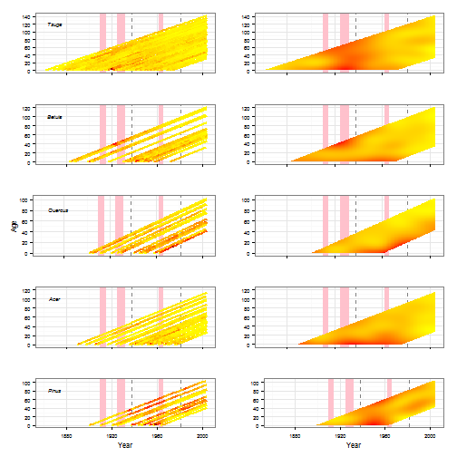

```r
a.lines <- ggplot(data = dendro.5sp[dendro.5sp$Code == "Acer", ], aes(x = Year,
    y = Age, group = TreeNum, geom = "line", xmin = 1860, ymax = 120, color = rBAI2,
    xlab = "", ylab = "Age")) +
# add environmental markers

geom_rect(xmin = 1910, xmax = 1915, ymin = -Inf, ymax = Inf, fill = "pink",
    alpha = 0.3, inherit.aes = FALSE) + geom_rect(xmin = 1925, xmax = 1932,
    ymin = -Inf, ymax = Inf, fill = "pink", alpha = 0.3, inherit.aes = FALSE) +
    geom_rect(xmin = 1962, xmax = 1966, ymin = -Inf, ymax = Inf, fill = "pink",
        alpha = 0.3, inherit.aes = FALSE) + geom_vline(xintercept = 1938, color = "grey50",
    linetype = 2, size = 0.25) + geom_vline(xintercept = 1981, color = "grey50",
    linetype = 2, size = 0.25) +
geom_line(size = 1) + scale_colour_gradientn(colours = c("yellow", "orange",
    "orangered", "red", "darkred")) + theme_bw() + theme(legend.position = "none",
    axis.title.x = element_blank(), axis.text.x = element_blank(), axis.title.y = element_text(colour = "white"),
    axis.text.y = element_text(size = 6), axis.ticks.length = unit(1, "mm"),
    axis.ticks = element_line(size = 0.25)) + scale_x_continuous(breaks = seq(1880,
    2000, 40)) + scale_y_continuous(breaks = seq(0, 120, 20)) + annotate("text",
    label = "Acer", x = 1870, y = 102, size = 2, colour = "black", fontface = 3)

p.lines <- ggplot(data = dendro.5sp[dendro.5sp$Code == "Pinus", ], aes(x = Year,
    y = Age, group = TreeNum, geom = "line", xmin = 1860, ymax = 100, color = rBAI2,
    xlab = "Year", ylab = "Age")) +
# add environmental markers

geom_rect(xmin = 1910, xmax = 1915, ymin = -Inf, ymax = Inf, fill = "pink",
    alpha = 0.3, inherit.aes = FALSE) + geom_rect(xmin = 1925, xmax = 1932,
    ymin = -Inf, ymax = Inf, fill = "pink", alpha = 0.3, inherit.aes = FALSE) +
    geom_rect(xmin = 1962, xmax = 1966, ymin = -Inf, ymax = Inf, fill = "pink",
        alpha = 0.3, inherit.aes = FALSE) + geom_vline(xintercept = 1938, color = "grey50",
    linetype = 2, size = 0.25) + geom_vline(xintercept = 1981, color = "grey50",
    linetype = 2, size = 0.25) +
geom_line(size = 1) + scale_colour_gradientn(colours = c("yellow", "orange",
    "orangered", "red", "darkred")) + theme_bw() + theme(legend.position = "none",
    axis.title.x = element_text(size = 8), axis.text.x = element_text(size = 6),
    axis.title.y = element_text(colour = "white"), axis.text.y = element_text(size = 6),
    axis.ticks.length = unit(1, "mm"), axis.ticks = element_line(size = 0.25)) +
    scale_x_continuous(breaks = seq(1880, 2000, 40)) + scale_y_continuous(breaks = seq(0,
    100, 20)) + annotate("text", label = "Pinus", x = 1870, y = 82, size = 2,
    colour = "black", fontface = 3)



# pdf('Figure-11-countours-v2.pdf', height=6, width=4)
multiplot(t.lines, b.lines, q.lines, a.lines, p.lines, t.cont, b.cont, q.cont,
    a.cont, p.cont, cols = 2)
```

```r
# dev.off()
```

Extract deviance from and compare the 1-d and 2-d GAMs

```r
1 - gam.acer1$deviance/gam.acer1$null.deviance
```

```
## [1] 0.2583
```

```r
1 - gam.acer2$deviance/gam.acer1$null.deviance
```

```
## [1] 0.2601
```

```r
AIC(gam.acer1, gam.acer2)
```

```
##               df   AIC
## gam.acer1 118.00 13156
## gam.acer2  26.63 12968
```

```r
1 - gam.betula1$deviance/gam.betula1$null.deviance
```

```
## [1] 0.3788
```

```r
1 - gam.betula2$deviance/gam.betula1$null.deviance
```

```
## [1] 0.4528
```

```r
AIC(gam.betula1, gam.betula2)
```

```
##                 df   AIC
## gam.betula1 125.00 13176
## gam.betula2  29.28 12728
```

```r
1 - gam.quercus1$deviance/gam.quercus1$null.deviance
```

```
## [1] 0.333
```

```r
1 - gam.quercus2$deviance/gam.quercus1$null.deviance
```

```
## [1] 0.4169
```

```r
AIC(gam.quercus1, gam.quercus2)
```

```
##                 df  AIC
## gam.quercus1 106.0 7989
## gam.quercus2  27.3 7671
```

```r
1 - gam.pinus1$deviance/gam.pinus1$null.deviance
```

```
## [1] 0.297
```

```r
1 - gam.pinus2$deviance/gam.pinus1$null.deviance
```

```
## [1] 0.3942
```

```r
AIC(gam.pinus1, gam.pinus2)
```

```
##                df  AIC
## gam.pinus1 108.00 7227
## gam.pinus2  27.62 6930
```

```r
1 - gam.tsuga1$deviance/gam.tsuga1$null.deviance
```

```
## [1] 0.2453
```

```r
1 - gam.tsuga2$deviance/gam.tsuga1$null.deviance
```

```
## [1] 0.2492
```

```r
AIC(gam.tsuga1, gam.tsuga2)
```

```
##                df   AIC
## gam.tsuga1 146.00 65388
## gam.tsuga2  30.22 65107
```